# SEM study 3

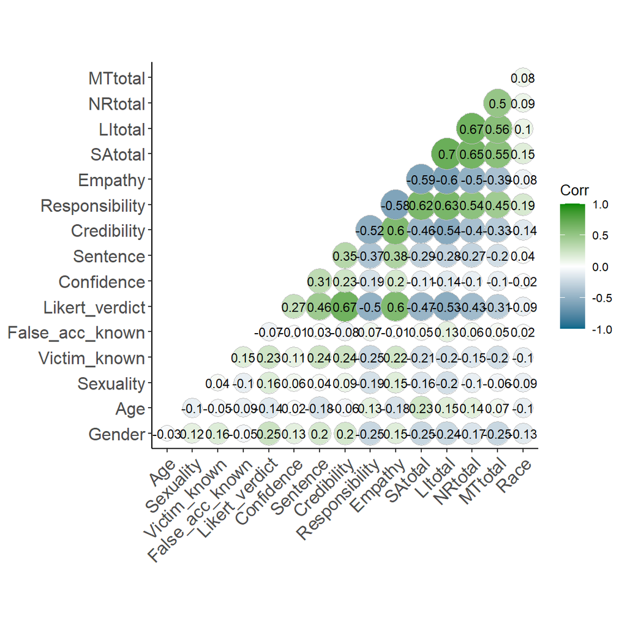

```r
corr<-round(cor(corrdata),2)
ggcorrplot(corr,type = "lower",
           lab = TRUE,
           lab_size = 3,
           method="circle",
           colors= c("deepskyblue4","white","green4"),
           ggtheme=theme_classic (base_family = "Times", base_size = 10))
```

```r
Guiltydata<-data[(data$Verdict==1),]
cor(Guiltydata$Likert_verdict, Guiltydata$Confidence)
```

```
## [1] 0.556445
```

```r
Notguiltydata<-data[(data$Verdict==0),]
cor(Notguiltydata$Likert_verdict, Notguiltydata$Confidence)
```

```
## [1] -0.3407999
```

# Mean Comparison

## Verdict t-tests

```r
options(scipen = 999)
verttest<-lapply(data[,c(3:13)],function(x)t.test(x~dataset$Verdict,var.eq=T))
vertable<-map_df(verttest, broom::tidy, .id="var")
vertable
```

```
## # A tibble: 11 x 11
##    var        estimate estimate1 estimate2 statistic  p.value parameter conf.low
##    <chr>         <dbl>     <dbl>     <dbl>     <dbl>    <dbl>     <dbl>    <dbl>
##  1 Likert_ve~   -1.82       4.33      6.15    -15.0  1.45e-39       345    -2.05
##  2 Confidence  -16.2       60.0      76.2      -6.96 1.72e-11       345   -20.8
##  3 Sentence     -3.30       1.17      4.48    -11.5  4.52e-26       345    -3.87
##  4 Credibili~   -1.43       4.64      6.07    -10.9  4.36e-24       345    -1.69
##  5 Responsib~    1.51       4.13      2.62      7.99 2.02e-14       345     1.14
##  6 Empathy      -0.978      3.11      4.08     -9.14 5.57e-18       345    -1.19
##  7 SAtotal       3.40       9.55      6.15      6.68 9.66e-11       345     2.40
##  8 LIplus        6.85      18.6      11.8       8.13 7.84e-15       345     5.19
##  9 LItotal       6.18      16.5      10.3       8.30 2.35e-15       345     4.71
## 10 NRtotal       2.75       8.22      5.47      7.53 4.48e-13       345     2.04
## 11 MTtotal       2.99      16.9      13.9       4.12 4.71e- 5       345     1.56
## # ... with 3 more variables: conf.high <dbl>, method <chr>, alternative <chr>
```

```r
print.data.frame(vertable)
```

```
##               var    estimate estimate1 estimate2  statistic
## 1  Likert_verdict  -1.8155039  4.333333  6.148837 -15.014092
## 2      Confidence -16.2413319 59.977273 76.218605  -6.959826
## 3        Sentence  -3.3048273  1.174242  4.479070 -11.484263
## 4     Credibility  -1.4304792  4.643939  6.074419 -10.932652
## 5  Responsibility   1.5101832  4.128788  2.618605   7.991905
## 6         Empathy  -0.9776603  3.106061  4.083721  -9.137602
## 7         SAtotal   3.3995419  9.553030  6.153488   6.678762
## 8          LIplus   6.8508457 18.613636 11.762791   8.129132
## 9         LItotal   6.1785412 16.522727 10.344186   8.302191
## 10        NRtotal   2.7545807  8.219697  5.465116   7.529806
## 11        MTtotal   2.9898872 16.901515 13.911628   4.122068
##                                            p.value parameter   conf.low
## 1  0.000000000000000000000000000000000000001452886       345  -2.053337
## 2  0.000000000017237102426941205811014579118989332       345 -20.831172
```

[output cut: 21 more lines]

```r
tvalues<-vertable$statistic
eta<-function(x){(x*x)/(x*x+(n-1))}
n=347
eta(tvalues)
```

```
##          t          t          t          t          t          t          t
## 0.39449406 0.12280518 0.27598142 0.25674974 0.15583103 0.19440417 0.11419661
##          t          t          t          t
## 0.16036290 0.16611713 0.14079528 0.04680948
```

```r
t.test(Credibility~Verdict,data,var.equal=T)
```

```
##
##  Two Sample t-test
##
## data:  Credibility by Verdict
## t = -10.933, df = 345, p-value < 0.00000000000000022
## alternative hypothesis: true difference in means between group 0 and group 1 is not equal to 0
## 95 percent confidence interval:
##  -1.687833 -1.173126
## sample estimates:
## mean in group 0 mean in group 1
##        4.643939        6.074419
```

```r
sapply(Guiltydata,sd)
```

```
##         Gender        Verdict Likert_verdict     Confidence       Sentence
##      0.5942929      0.0000000      0.7890525     20.9026142      2.8495415
##    Credibility Responsibility        Empathy        SAtotal         LIplus
##      1.0294933      1.7222100      0.8385931      3.8377946      6.7272991
##        LItotal        NRtotal        MTtotal       RMAtotal
##      5.9939729      2.5407781      6.3897263     15.2679509
```

```r
sapply(Notguiltydata,sd)
```

```
##         Gender        Verdict Likert_verdict     Confidence       Sentence
##      0.5451509      0.0000000      1.4602450     21.4289046      2.1383314
##    Credibility Responsibility        Empathy        SAtotal         LIplus
##      1.3986503      1.6869744      1.1475668      5.6342930      8.8908974
##        LItotal        NRtotal        MTtotal       RMAtotal
##      7.7847629      4.2754659      6.8281633     20.5398289
```

Boxplot

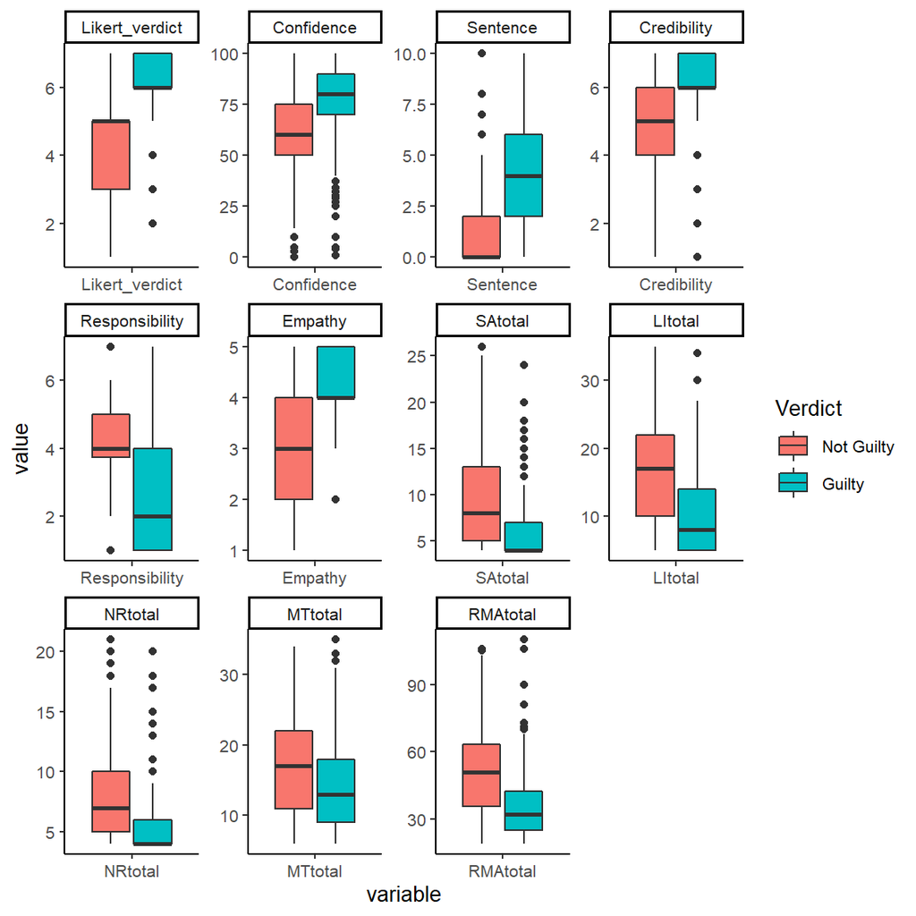

```r
datalong<-melt(data[,c(2:9, 11:14)], id.var=c("Verdict"))
box1 <- ggplot(data = datalong, aes(x=variable, y=value, fill=factor(Verdict))) + geom_boxplot()
box1 + facet_wrap( ~ variable, scales="free")+theme_classic(base_size = 10)+  scale_fill_discrete(name = "Verdict", labels = c("Not Guilty", "Guilty"))
```

## Gender differences

```r
Sex<-factor(data$Gender,levels = c(1,2),labels = c( "Male","Female"))
datas<-cbind(data, Sex= as.numeric(Sex))

sexttest<-lapply(data[,c(3:9, 11:14)], function(x)t.test(x~Sex,var.eq=F))
sexttable<-map_df(sexttest,broom::tidy, .id="var")
sexttable
```

```
## # A tibble: 11 x 11
##    var            estimate estimate1 estimate2 statistic p.value parameter conf.low
##    <chr>             <dbl>     <dbl>     <dbl>     <dbl>   <dbl>     <dbl>    <dbl>
##  1 Likert_verdict   -0.741      4.97      5.71     -4.40 1.81e-5      195.   -1.07
##  2 Confidence       -5.88      66.1      71.9      -2.25 2.54e-2      230.  -11.0
##  3 Sentence         -1.35       2.35      3.69     -4.10 5.53e-5      270.   -1.99
##  4 Credibility      -0.660      5.11      5.77     -4.10 5.96e-5      201.   -0.977
##  5 Responsibility    0.950      3.83      2.88      4.70 4.33e-6      256.    0.551
##  6 Empathy          -0.412      3.45      3.86     -3.25 1.35e-3      214.   -0.662
##  7 SAtotal           2.56       9.17      6.60      4.58 7.90e-6      222.    1.46
##  8 LItotal           3.73      15.2      11.4       4.54 8.73e-6      240.    2.12
##  9 NRtotal           1.18       7.31      6.14      2.81 5.40e-3      219.    0.351
## 10 MTtotal           3.62      17.4      13.8       4.92 1.53e-6      252.    2.17
## 11 RMAtotal         11.1       49.1      38.0       5.26 3.32e-7      235.    6.93
## # ... with 3 more variables: conf.high <dbl>, method <chr>, alternative <chr>
```

```r
print.data.frame(sexttable)
```

```
##               var   estimate estimate1 estimate2 statistic         p.value
## 1  Likert_verdict -0.7408204  4.966942  5.707763 -4.395956 0.0000181246928
## 2      Confidence -5.8827880 66.057851 71.940639 -2.250671 0.0253515079270
## 3        Sentence -1.3469565  2.347107  3.694064 -4.097279 0.0000553113719
## 4     Credibility -0.6596853  5.107438  5.767123 -4.101537 0.0000595705250
## 5  Responsibility  0.9497340  3.826446  2.876712  4.696077 0.0000043266570
## 6         Empathy -0.4121665  3.446281  3.858447 -3.248271 0.0013476879485
## 7         SAtotal  2.5625495  9.165289  6.602740  4.575560 0.0000079041355
## 8         LItotal  3.7343296 15.181818 11.447489  4.544452 0.0000087257007
## 9         NRtotal  1.1770633  7.314050  6.136986  2.809881 0.0054049132677
## 10        MTtotal  3.6160987 17.438017 13.821918  4.924698 0.0000015303729
## 11       RMAtotal 11.0900411 49.099174 38.009132  5.255245 0.0000003316516
##    parameter    conf.low  conf.high                  method alternative
## 1   194.5285  -1.0731875 -0.4084533 Welch Two Sample t-test   two.sided
## 2   230.1096 -11.0328145 -0.7327615 Welch Two Sample t-test   two.sided
## 3   270.1548  -1.9941827 -0.6997303 Welch Two Sample t-test   two.sided
## 4   201.1589  -0.9768311 -0.3425395 Welch Two Sample t-test   two.sided
## 5   256.2537   0.5514701  1.3479978 Welch Two Sample t-test   two.sided
## 6   214.4680  -0.6622737 -0.1620593 Welch Two Sample t-test   two.sided
## 7   221.7651   1.4588455  3.6662536 Welch Two Sample t-test   two.sided
## 8   240.4161   2.1156124  5.3530468 Welch Two Sample t-test   two.sided
## 9   218.8783   0.3514666  2.0026599 Welch Two Sample t-test   two.sided
## 10  251.8878   2.1699917  5.0622057 Welch Two Sample t-test   two.sided
## 11  234.8945   6.9325465 15.2475358 Welch Two Sample t-test   two.sided
```

```r
tvalues2<-sexttable$statistic
eta(tvalues2)
```

```
##          t          t          t          t          t          t          t
## 0.05289663 0.01442899 0.04627416 0.04636593 0.05991835 0.02959257 0.05705564
##          t          t          t          t
## 0.05632600 0.02231007 0.06550299 0.07391943
```

Boxplot

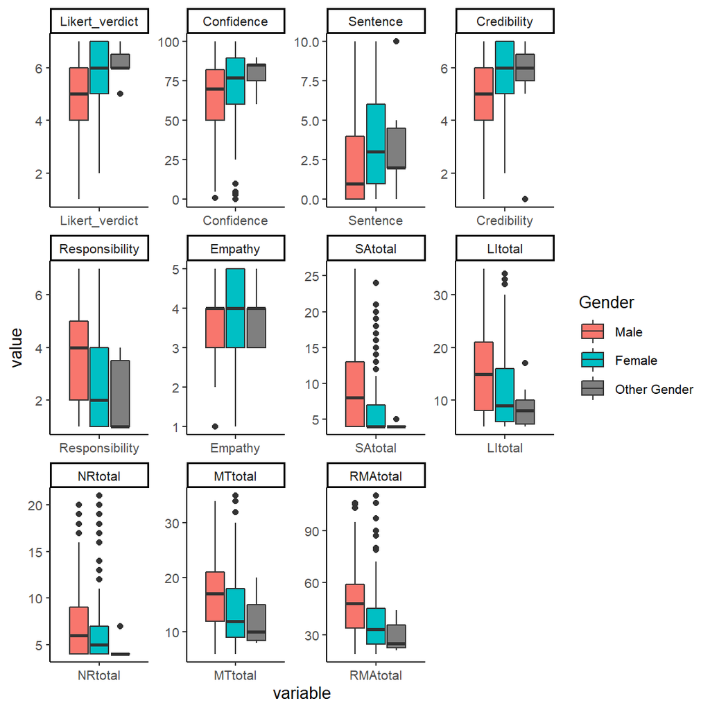

```r
datalong2<-melt(datas[,c(3:9, 11:15)], id.var=c("Sex"))
box2 <- ggplot(data = datalong2, aes(x=variable, y=value, fill=factor(Sex))) + geom_boxplot()
box2 + facet_wrap( ~ variable, scales="free")+theme_classic(base_size = 10)+  scale_fill_discrete(name = "Gender", labels = c("Male", "Female", "Other Gender"))
```

Chi-square test

```r
options(scipen=999)
Guilt<-factor(data$Verdict,levels = c(0,1),labels = c("Not Guilty", "Guilty"))
datas<-cbind(datas,Guilt)
chitable<-table(Sex,Guilt)
chisq.test(chitable, correct = T)
```

```
##
##  Pearson's Chi-squared test with Yates' continuity correction
##
## data:  chitable
## X-squared = 17.318, df = 1, p-value = 0.00003162
```

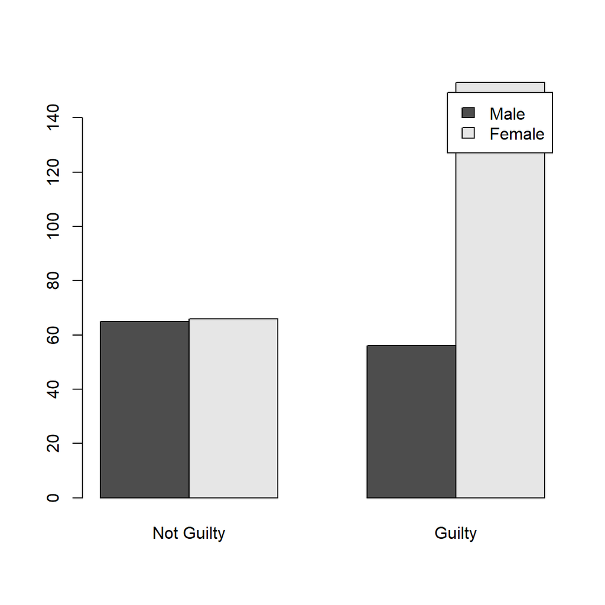

```r
barplot(chitable, beside=T, legend=T)
```

# Hierarchical regression

```r
regoutput1=lm(Likert_verdict~Gender+Confidence,data)
summary(regoutput1)
```

```
##
## Call:
## lm(formula = Likert_verdict ~ Gender + Confidence, data = data)
##
## Residuals:
##     Min      1Q  Median      3Q     Max
## -4.5576 -0.5121  0.2294  0.9253  2.6589
##
## Coefficients:
##             Estimate Std. Error t value             Pr(>|t|)
## (Intercept) 3.519930   0.290986  12.097 < 0.0000000000000002 ***
## Gender      0.517099   0.121422   4.259           0.00002657 ***
## Confidence  0.015206   0.003183   4.778           0.00000263 ***
## ---
## Signif. codes:  0 '***' 0.001 '**' 0.01 '*' 0.05 '.' 0.1 ' ' 1
##
## Residual standard error: 1.321 on 344 degrees of freedom
## Multiple R-squared:  0.1206, Adjusted R-squared:  0.1155
## F-statistic: 23.59 on 2 and 344 DF,  p-value: 0.0000000002519
```

```r
lm.beta(regoutput1)
```

```
##
## Call:
## lm(formula = Likert_verdict ~ Gender + Confidence, data = data)
##
## Standardized Coefficients::
## (Intercept)      Gender  Confidence
##          NA   0.2172322   0.2437123
```

```r
apa.reg.table(regoutput1)
```

```
##
##
## Regression results using Likert_verdict as the criterion
##
##
##    Predictor      b     b_95%_CI beta  beta_95%_CI sr2 sr2_95%_CI     r
##  (Intercept) 3.52** [2.95, 4.09]
##       Gender 0.52** [0.28, 0.76] 0.22 [0.12, 0.32] .05 [.00, .09] .25**
##   Confidence 0.02** [0.01, 0.02] 0.24 [0.14, 0.34] .06 [.01, .10] .27**
##
##
##
##              Fit
##
##
##
##      R2 = .121**
##  95% CI[.06,.18]
##
##
## Note. A significant b-weight indicates the beta-weight and semi-partial correlation are also significant.
## b represents unstandardized regression weights. beta indicates the standardized regression weights.
## sr2 represents the semi-partial correlation squared. r represents the zero-order correlation.
## Square brackets are used to enclose the lower and upper limits of a confidence interval.
## * indicates p < .05. ** indicates p < .01.
##
```

## Step 2

```r
regoutput2=lm(Likert_verdict~Gender+Confidence+SAtotal+NRtotal+LItotal,data)
summary(regoutput2)
```

```
##
## Call:
## lm(formula = Likert_verdict ~ Gender + Confidence + SAtotal +
##     NRtotal + LItotal, data = data)
##
## Residuals:
##     Min      1Q  Median      3Q     Max
## -4.4896 -0.4699  0.1587  0.7228  3.6787
##
## Coefficients:
##              Estimate Std. Error t value             Pr(>|t|)
## (Intercept)  5.555020   0.312287  17.788 < 0.0000000000000002 ***
## Gender       0.227973   0.108316   2.105               0.0360 *
## Confidence   0.011782   0.002764   4.263           0.00002615 ***
## SAtotal     -0.041763   0.018901  -2.210               0.0278 *
## NRtotal     -0.032017   0.024596  -1.302               0.1939
## LItotal     -0.062036   0.012782  -4.853           0.00000185 ***
## ---
## Signif. codes:  0 '***' 0.001 '**' 0.01 '*' 0.05 '.' 0.1 ' ' 1
##
## Residual standard error: 1.139 on 341 degrees of freedom
## Multiple R-squared:  0.3516, Adjusted R-squared:  0.3421
## F-statistic: 36.99 on 5 and 341 DF,  p-value: < 0.00000000000000022
```

```r
lm.beta(regoutput2)
```

```
##
## Call:
## lm(formula = Likert_verdict ~ Gender + Confidence + SAtotal +
##     NRtotal + LItotal, data = data)
##
## Standardized Coefficients::
## (Intercept)      Gender  Confidence     SAtotal     NRtotal     LItotal
##          NA  0.09577113  0.18884073 -0.14528842 -0.08128371 -0.32523815
```

```r
apa.reg.table(regoutput2)
```

```
##
##
## Regression results using Likert_verdict as the criterion
##
##
##    Predictor       b       b_95%_CI  beta    beta_95%_CI sr2  sr2_95%_CI      r
##  (Intercept)  5.56**   [4.94, 6.17]
##       Gender   0.23*   [0.01, 0.44]  0.10   [0.01, 0.19] .01 [-.01, .02]  .25**
##   Confidence  0.01**   [0.01, 0.02]  0.19   [0.10, 0.28] .03  [.00, .07]  .27**
##      SAtotal  -0.04* [-0.08, -0.00] -0.15 [-0.27, -0.02] .01 [-.01, .03] -.47**
##      NRtotal   -0.03  [-0.08, 0.02] -0.08  [-0.20, 0.04] .00 [-.01, .01] -.43**
##      LItotal -0.06** [-0.09, -0.04] -0.33 [-0.46, -0.19] .04  [.01, .08] -.53**
##
##
##
##              Fit
##
##
##
##
##
##
##      R2 = .352**
##  95% CI[.27,.41]
##
##
## Note. A significant b-weight indicates the beta-weight and semi-partial correlation are also significant.
## b represents unstandardized regression weights. beta indicates the standardized regression weights.
## sr2 represents the semi-partial correlation squared. r represents the zero-order correlation.
## Square brackets are used to enclose the lower and upper limits of a confidence interval.
## * indicates p < .05. ** indicates p < .01.
##
```

## Step 3

```r
regoutput3=lm(Likert_verdict~Gender+Confidence+SAtotal+NRtotal+LItotal+Credibility+Responsibility+Empathy,data)
summary(regoutput3)
```

```
##
## Call:
## lm(formula = Likert_verdict ~ Gender + Confidence + SAtotal +
##     NRtotal + LItotal + Credibility + Responsibility + Empathy,
##     data = data)
##
## Residuals:
##     Min      1Q  Median      3Q     Max
## -4.4404 -0.4586  0.0909  0.5426  3.0258
##
## Coefficients:
##                 Estimate Std. Error t value            Pr(>|t|)
## (Intercept)     1.767405   0.469352   3.766            0.000196 ***
## Gender          0.193452   0.092522   2.091            0.037284 *
## Confidence      0.006094   0.002395   2.545            0.011378 *
## SAtotal        -0.003733   0.016944  -0.220            0.825775
## NRtotal        -0.017799   0.020977  -0.848            0.396770
## LItotal        -0.016108   0.011673  -1.380            0.168494
## Credibility     0.411173   0.050672   8.114 0.00000000000000916 ***
## Responsibility -0.027107   0.040298  -0.673            0.501624
## Empathy         0.295859   0.070092   4.221 0.00003129229810424 ***
## ---
## Signif. codes:  0 '***' 0.001 '**' 0.01 '*' 0.05 '.' 0.1 ' ' 1
##
## Residual standard error: 0.9643 on 338 degrees of freedom
## Multiple R-squared:  0.5392, Adjusted R-squared:  0.5283
## F-statistic: 49.44 on 8 and 338 DF,  p-value: < 0.00000000000000022
```

```r
lm.beta(regoutput3)
```

```
##
## Call:
## lm(formula = Likert_verdict ~ Gender + Confidence + SAtotal +
##     NRtotal + LItotal + Credibility + Responsibility + Empathy,
##     data = data)
##
## Standardized Coefficients::
##    (Intercept)         Gender     Confidence        SAtotal        NRtotal
##             NA     0.08126892     0.09766710    -0.01298521    -0.04518706
##        LItotal    Credibility Responsibility        Empathy
##    -0.08445254     0.40150212    -0.03586394     0.22689094
```

## Regression Model comparison

```r
anova(regoutput1,regoutput2)
```

```
## Analysis of Variance Table
##
## Model 1: Likert_verdict ~ Gender + Confidence
## Model 2: Likert_verdict ~ Gender + Confidence + SAtotal + NRtotal + LItotal
##   Res.Df    RSS Df Sum of Sq      F                Pr(>F)
## 1    344 599.89
## 2    341 442.29  3     157.6 40.502 < 0.00000000000000022 ***
## ---
## Signif. codes:  0 '***' 0.001 '**' 0.01 '*' 0.05 '.' 0.1 ' ' 1
```

```r
anova(regoutput1,regoutput2,regoutput3)
```

```
## Analysis of Variance Table
##
## Model 1: Likert_verdict ~ Gender + Confidence
## Model 2: Likert_verdict ~ Gender + Confidence + SAtotal + NRtotal + LItotal
## Model 3: Likert_verdict ~ Gender + Confidence + SAtotal + NRtotal + LItotal +
##     Credibility + Responsibility + Empathy
##   Res.Df    RSS Df Sum of Sq      F                Pr(>F)
## 1    344 599.89
## 2    341 442.29  3    157.60 56.491 < 0.00000000000000022 ***
## 3    338 314.31  3    127.97 45.873 < 0.00000000000000022 ***
## ---
## Signif. codes:  0 '***' 0.001 '**' 0.01 '*' 0.05 '.' 0.1 ' ' 1
```

```r
apa.reg.table(regoutput3)
```

```
##
##
## Regression results using Likert_verdict as the criterion
##
##
##       Predictor      b      b_95%_CI  beta   beta_95%_CI sr2  sr2_95%_CI      r
##     (Intercept) 1.77**  [0.84, 2.69]
##          Gender  0.19*  [0.01, 0.38]  0.08  [0.00, 0.16] .01 [-.01, .02]  .25**
##      Confidence  0.01*  [0.00, 0.01]  0.10  [0.02, 0.17] .01 [-.00, .02]  .27**
##         SAtotal  -0.00 [-0.04, 0.03] -0.01 [-0.13, 0.10] .00 [-.00, .00] -.47**
##         NRtotal  -0.02 [-0.06, 0.02] -0.05 [-0.15, 0.06] .00 [-.00, .01] -.43**
##         LItotal  -0.02 [-0.04, 0.01] -0.08 [-0.20, 0.04] .00 [-.00, .01] -.53**
##     Credibility 0.41**  [0.31, 0.51]  0.40  [0.30, 0.50] .09  [.05, .13]  .67**
##  Responsibility  -0.03 [-0.11, 0.05] -0.04 [-0.14, 0.07] .00 [-.00, .00] -.50**
##         Empathy 0.30**  [0.16, 0.43]  0.23  [0.12, 0.33] .02  [.00, .05]  .60**
##
##
##
##              Fit
##
##
##
##
##
##
##
##
##
##      R2 = .539**
##  95% CI[.46,.59]
##
##
## Note. A significant b-weight indicates the beta-weight and semi-partial correlation are also significant.
## b represents unstandardized regression weights. beta indicates the standardized regression weights.
## sr2 represents the semi-partial correlation squared. r represents the zero-order correlation.
## Square brackets are used to enclose the lower and upper limits of a confidence interval.
## * indicates p < .05. ** indicates p < .01.
##
```

```r
tbl_regression(regoutput3)
```

| **Characteristic** | **Beta** | **95% CI**<sup>1</sup> | **p-value** |
| --- | --- | --- | --- |
| Gender | 0.19 | 0.01, 0.38 | 0.037 |
| Confidence | 0.01 | 0.00, 0.01 | 0.011 |
| SAtotal | 0.00 | -0.04, 0.03 | 0.8 |
| NRtotal | -0.02 | -0.06, 0.02 | 0.4 |
| LItotal | -0.02 | -0.04, 0.01 | 0.2 |
| Credibility | 0.41 | 0.31, 0.51 | <0.001 |
| Responsibility | -0.03 | -0.11, 0.05 | 0.5 |
| Empathy | 0.30 | 0.16, 0.43 | <0.001 |

<sup>*1*</sup> CI = Confidence Interval

# Logistic regression

```r
logmodel<-glm(Verdict~ SAtotal + LItotal + NRtotal + Credibility + Responsibility + Empathy, family = binomial(link = logit), data= data)
summary(logmodel)
```

```
##
## Call:
## glm(formula = Verdict ~ SAtotal + LItotal + NRtotal + Credibility +
##     Responsibility + Empathy, family = binomial(link = logit),
##     data = data)
##
## Deviance Residuals:
##     Min       1Q   Median       3Q      Max
## -2.2950  -0.8064   0.4678   0.7257   2.4138
##
## Coefficients:
##                Estimate Std. Error z value   Pr(>|z|)
## (Intercept)    -3.31891    1.09269  -3.037    0.00239 **
## SAtotal         0.03561    0.04147   0.859    0.39062
## LItotal        -0.02249    0.02824  -0.796    0.42574
## NRtotal        -0.11378    0.05378  -2.116    0.03438 *
## Credibility     0.65725    0.13483   4.875 0.00000109 ***
## Responsibility -0.09207    0.09967  -0.924    0.35561
## Empathy         0.35377    0.17504   2.021    0.04327 *
## ---
## Signif. codes:  0 '***' 0.001 '**' 0.01 '*' 0.05 '.' 0.1 ' ' 1
##
## (Dispersion parameter for binomial family taken to be 1)
##
##     Null deviance: 461.00  on 346  degrees of freedom
## Residual deviance: 340.11  on 340  degrees of freedom
## AIC: 354.11
##
## Number of Fisher Scoring iterations: 4
```

```r
logmodel%>%
  tbl_regression(exponentiate = TRUE)%>% add_vif()
```

| **Characteristic** | **OR**<sup>1</sup> | **95% CI**<sup>1</sup> | **p-value** | **VIF**<sup>1</sup> |
| --- | --- | --- | --- | --- |
| SAtotal | 1.04 | 0.96, 1.12 | 0.4 | 2.0 |
| LItotal | 0.98 | 0.93, 1.03 | 0.4 | 2.0 |
| NRtotal | 0.89 | 0.80, 0.99 | 0.034 | 1.7 |
| Credibility | 1.93 | 1.50, 2.55 | <0.001 | 1.3 |
| Responsibility | 0.91 | 0.75, 1.11 | 0.4 | 1.7 |
| Empathy | 1.42 | 1.01, 2.01 | 0.043 | 1.5 |

<sup>*1*</sup> OR = Odds Ratio, CI = Confidence Interval, VIF = Variance Inflation Factor

The test below checks whether the change in errors is significantly less for the model without predictors (i.e. if overall model sig)

```r
options(scipen = 999)
chidiff<-logmodel$null.deviance-logmodel$deviance
dfdiff<-logmodel$df.null-logmodel$df.residual
chidiff
```

```
## [1] 120.8887
```

```r
dfdiff
```

```
## [1] 6
```

```r
pchisq(chidiff, dfdiff, lower.tail = F)
```

```
## [1] 0.00000000000000000000001060225
```

```r
PseudoR2(logmodel)
```

```
##         McFadden     Adj.McFadden        Cox.Snell       Nagelkerke
##        0.2622330        0.2275256        0.2941711        0.4001611
## McKelvey.Zavoina           Effron            Count        Adj.Count
##        0.4163570        0.3283034        0.7867435        0.4393939
##              AIC    Corrected.AIC
##      354.1086225      354.4390060
```

```r
correct<-logmodel$fitted.values
binarycorrect<-ifelse(correct>0.5,1,0)
binarycorrect<-factor(binarycorrect, levels=c(0,1), labels=c("Not Predicted","Predicted"))
Verdict<-factor(data$Verdict, levels = c(0,1), labels = c("Not Guilty", "Guilty"))
table(data$Verdict, binarycorrect)
```

```
##    binarycorrect
##     Not Predicted Predicted
##   0            85        47
##   1            27       188
```

# Mediation Analysis

```r
Verdict<-data$Verdict
LItotal<-data$LItotal
Credibility<-data$Credibility
SAtotal<-data$SAtotal
Responsibility<-data$Responsibility
NRtotal<-data$NRtotal
Empathy<-data$Empathy
```

## Credibility

```r
med1 <- '
    # direct effect
      Verdict ~ c*LItotal
      direct := c

    # regressions
      Credibility ~ a*LItotal
      Verdict ~ b*Credibility

    # indirect effect (a*b)
      indirect := a*b

    # total effect
      total := c + (a*b)
'
credmed <- sem(med1, data = data, ordered = c("Verdict"), se = "bootstrap", bootstrap = 5000, estimator= "DWLS")
```

When the ordered= argument is used, lavaan will automatically switch to the WLSMV estimator but diagonally weighted least squares (DWLS) is used estimate the model parameters. However, it will use the full weight matrix to compute robust standard errors, and a mean- and variance-adjusted test statistic (Rosseel, 2021).

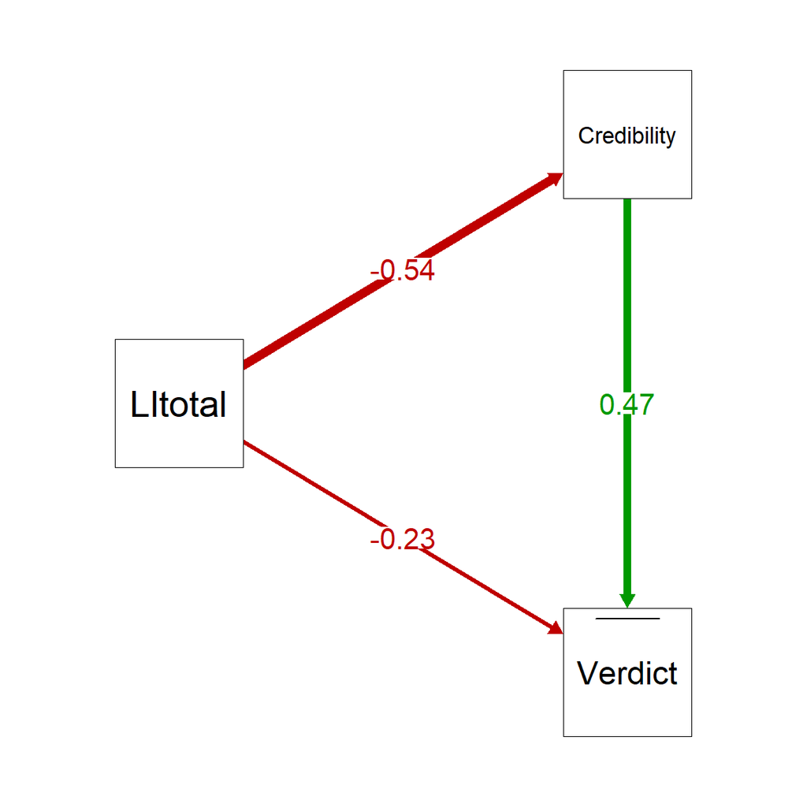

```r
semPaths(credmed, what="std",whatLabels = "std", sizeMan = 15, sizeInt = 15, sizeLat = 15,edge.label.cex=1.5, rotation=2, style = "lisrel", intercepts = F, residuals = F, nCharNodes=0, fade=F)
```

```r
summary(credmed, standardize = TRUE, rsquare = TRUE)
```

```
## lavaan 0.6-11 ended normally after 18 iterations
##
##   Estimator                                       DWLS
##   Optimization method                           NLMINB
##   Number of model parameters                         6
##
##   Number of observations                           347
##
## Model Test User Model:
##
##   Test statistic                                 0.000
##   Degrees of freedom                                 0
##
## Parameter Estimates:
##
##   Standard errors                            Bootstrap
##   Number of requested bootstrap draws             5000
##   Number of successful bootstrap draws            5000
##
## Regressions:
##                    Estimate  Std.Err  z-value  P(>|z|)   Std.lv  Std.all
##   Verdict ~
##     LItotal    (c)   -0.036    0.013   -2.790    0.005   -0.036   -0.230
##   Credibility ~
##     LItotal    (a)   -0.100    0.010   -9.762    0.000   -0.100   -0.539
##   Verdict ~
##     Credibilty (b)    0.395    0.079    5.029    0.000    0.395    0.473
##
## Intercepts:
##                    Estimate  Std.Err  z-value  P(>|z|)   Std.lv  Std.all
##    .Verdict           0.000                               0.000    0.000
##    .Credibility       6.804    0.126   54.192    0.000    6.804    4.967
##
## Thresholds:
##                    Estimate  Std.Err  z-value  P(>|z|)   Std.lv  Std.all
##     Verdict|t1        1.399    0.569    2.458    0.014    1.399    1.223
##
## Variances:
##                    Estimate  Std.Err  z-value  P(>|z|)   Std.lv  Std.all
##    .Verdict           0.792                               0.792    0.606
##    .Credibility       1.331    0.144    9.248    0.000    1.331    0.709
##
## Scales y*:
##                    Estimate  Std.Err  z-value  P(>|z|)   Std.lv  Std.all
##     Verdict           1.000                               1.000    1.000
##
## R-Square:
##                    Estimate
##     Verdict           0.394
##     Credibility       0.291
##
## Defined Parameters:
##                    Estimate  Std.Err  z-value  P(>|z|)   Std.lv  Std.all
##     direct           -0.036    0.013   -2.794    0.005   -0.036   -0.230
##     indirect         -0.040    0.009   -4.370    0.000   -0.040   -0.255
##     total            -0.075    0.011   -7.043    0.000   -0.075   -0.485
```

```r
parameterestimates(credmed, standardized = TRUE, boot.ci.type = "bca.simple")
```

```
##            lhs  op         rhs    label    est    se      z pvalue ci.lower
## 1      Verdict   ~     LItotal        c -0.036 0.013 -2.790  0.005   -0.062
## 2  Credibility   ~     LItotal        a -0.100 0.010 -9.762  0.000   -0.120
## 3      Verdict   ~ Credibility        b  0.395 0.079  5.029  0.000    0.267
## 4      Verdict   |          t1           1.399 0.569  2.458  0.014    0.460
## 5      Verdict  ~~     Verdict           0.792 0.000     NA     NA    0.792
## 6  Credibility  ~~ Credibility           1.331 0.144  9.248  0.000    1.075
## 7      LItotal  ~~     LItotal          54.190 0.000     NA     NA   54.190
## 8      Verdict ~*~     Verdict           1.000 0.000     NA     NA    1.000
## 9      Verdict  ~1                       0.000 0.000     NA     NA    0.000
## 10 Credibility  ~1                       6.804 0.126 54.192  0.000    6.550
## 11     LItotal  ~1                      12.695 0.000     NA     NA   12.695
## 12      direct  :=           c   direct -0.036 0.013 -2.794  0.005   -0.062
## 13    indirect  :=         a*b indirect -0.040 0.009 -4.370  0.000   -0.059
## 14       total  :=     c+(a*b)    total -0.075 0.011 -7.043  0.000   -0.097
##    ci.upper std.lv std.all std.nox
## 1    -0.011 -0.036  -0.230  -0.031
## 2    -0.080 -0.100  -0.539  -0.073
## 3     0.567  0.395   0.473   0.473
## 4     2.659  1.399   1.223   1.223
## 5     0.792  0.792   0.606   0.606
## 6     1.651  1.331   0.709   0.709
## 7    54.190 54.190   1.000  54.190
## 8     1.000  1.000   1.000   1.000
## 9     0.000  0.000   0.000   0.000
## 10    7.040  6.804   4.967   4.967
## 11   12.695 12.695   1.724  12.695
## 12   -0.011 -0.036  -0.230  -0.031
## 13   -0.025 -0.040  -0.255  -0.035
## 14   -0.055 -0.075  -0.485  -0.066
```

## Responsibility

```r
med2 <- '
    # direct effect
      Verdict ~ c*SAtotal
      direct := c

    # regressions
      Responsibility ~ a*SAtotal
      Verdict ~ b*Responsibility

    # indirect effect (a*b)
      indirect := a*b

    # total effect
      total := c + (a*b)
'
respmed <- sem(med2, data = data, ordered = c("Verdict"), se = "bootstrap", bootstrap = 5000, estimator= "DWLS")
```

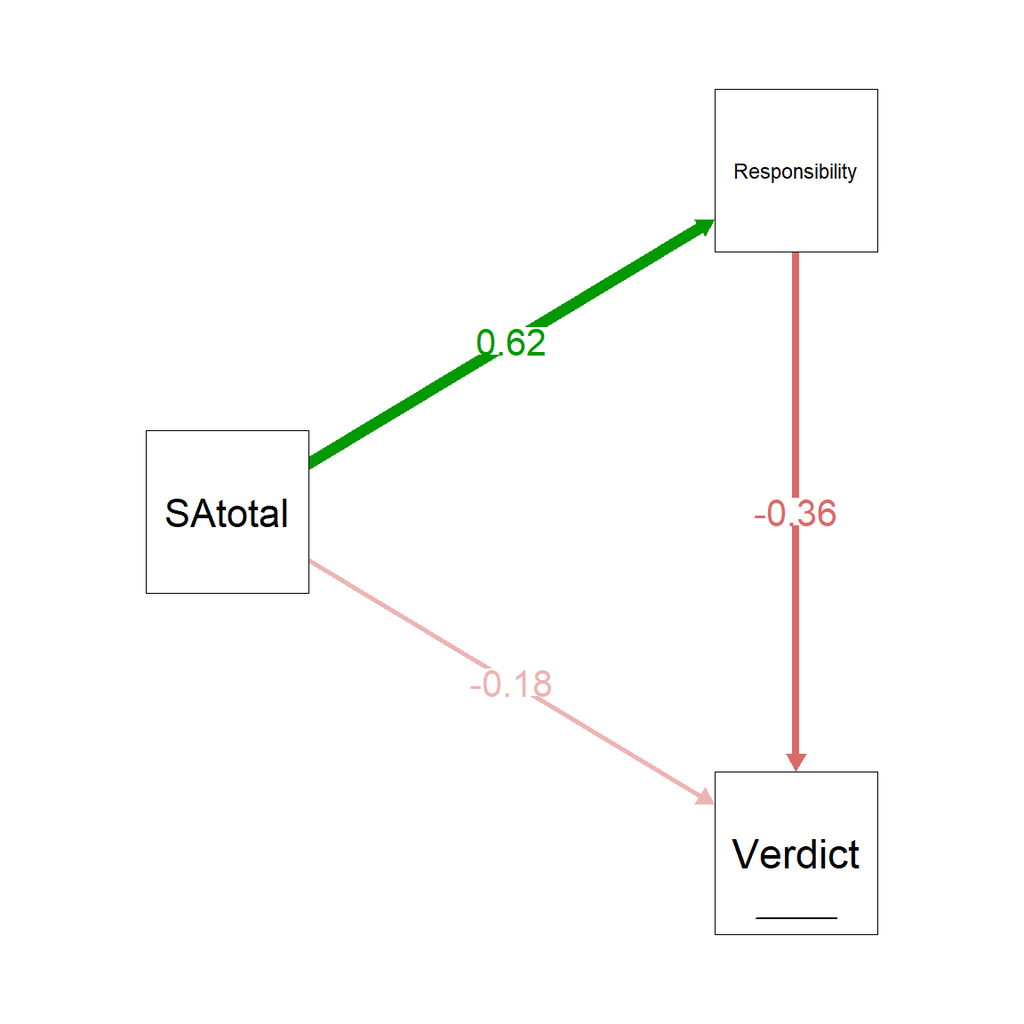

```r
semPaths(respmed, what="std",whatLabels = "std", sizeMan = 15, sizeInt = 15, sizeLat = 15,edge.label.cex=1.5, rotation=2, style = "lisrel", intercepts = F, residuals = F, nCharNodes=0)
```

```r
summary(respmed, standardize = TRUE, rsquare = TRUE)
```

```
## lavaan 0.6-11 ended normally after 20 iterations
##
##   Estimator                                       DWLS
##   Optimization method                           NLMINB
##   Number of model parameters                         6
##
##   Number of observations                           347
##
## Model Test User Model:
##
##   Test statistic                                 0.000
##   Degrees of freedom                                 0
##
## Parameter Estimates:
##
##   Standard errors                            Bootstrap
##   Number of requested bootstrap draws             5000
##   Number of successful bootstrap draws            5000
##
## Regressions:
##                    Estimate  Std.Err  z-value  P(>|z|)   Std.lv  Std.all
##   Verdict ~
##     SAtotal    (c)   -0.041    0.020   -2.074    0.038   -0.041   -0.183
##   Responsibility ~
##     SAtotal    (a)    0.236    0.013   17.599    0.000    0.236    0.622
##   Verdict ~
##     Respnsblty (b)   -0.214    0.044   -4.821    0.000   -0.214   -0.363
##
## Intercepts:
##                    Estimate  Std.Err  z-value  P(>|z|)   Std.lv  Std.all
##    .Verdict           0.000                               0.000    0.000
##    .Responsibility    1.433    0.144    9.984    0.000    1.433    0.772
##
## Thresholds:
##                    Estimate  Std.Err  z-value  P(>|z|)   Std.lv  Std.all
##     Verdict|t1       -1.307    0.143   -9.168    0.000   -1.307   -1.193
##
## Variances:
##                    Estimate  Std.Err  z-value  P(>|z|)   Std.lv  Std.all
##    .Verdict           0.903                               0.903    0.752
##    .Responsibility    2.112    0.152   13.881    0.000    2.112    0.613
##
## Scales y*:
##                    Estimate  Std.Err  z-value  P(>|z|)   Std.lv  Std.all
##     Verdict           1.000                               1.000    1.000
##
## R-Square:
##                    Estimate
##     Verdict           0.248
##     Responsibility    0.387
##
## Defined Parameters:
##                    Estimate  Std.Err  z-value  P(>|z|)   Std.lv  Std.all
##     direct           -0.041    0.020   -2.076    0.038   -0.041   -0.183
##     indirect         -0.051    0.011   -4.580    0.000   -0.051   -0.226
##     total            -0.092    0.017   -5.530    0.000   -0.092   -0.409
```

```r
parameterestimates(respmed, standardized = TRUE, boot.ci.type = "bca.simple")
```

```
##               lhs  op            rhs    label    est    se      z pvalue
## 1         Verdict   ~        SAtotal        c -0.041 0.020 -2.074  0.038
## 2  Responsibility   ~        SAtotal        a  0.236 0.013 17.599  0.000
## 3         Verdict   ~ Responsibility        b -0.214 0.044 -4.821  0.000
## 4         Verdict   |             t1          -1.307 0.143 -9.168  0.000
## 5         Verdict  ~~        Verdict           0.903 0.000     NA     NA
## 6  Responsibility  ~~ Responsibility           2.112 0.152 13.881  0.000
## 7         SAtotal  ~~        SAtotal          23.861 0.000     NA     NA
## 8         Verdict ~*~        Verdict           1.000 0.000     NA     NA
## 9         Verdict  ~1                          0.000 0.000     NA     NA
## 10 Responsibility  ~1                          1.433 0.144  9.984  0.000
## 11        SAtotal  ~1                          7.447 0.000     NA     NA
## 12         direct  :=              c   direct -0.041 0.020 -2.076  0.038
## 13       indirect  :=            a*b indirect -0.051 0.011 -4.580  0.000
## 14          total  :=        c+(a*b)    total -0.092 0.017 -5.530  0.000
##    ci.lower ci.upper std.lv std.all std.nox
## 1    -0.084   -0.005 -0.041  -0.183  -0.037
## 2     0.210    0.263  0.236   0.622   0.127
## 3    -0.299   -0.124 -0.214  -0.363  -0.363
## 4    -1.585   -1.029 -1.307  -1.193  -1.193
## 5     0.903    0.903  0.903   0.752   0.752
## 6     1.840    2.438  2.112   0.613   0.613
## 7    23.861   23.861 23.861   1.000  23.861
## 8     1.000    1.000  1.000   1.000   1.000
## 9     0.000    0.000  0.000   0.000   0.000
## 10    1.154    1.717  1.433   0.772   0.772
## 11    7.447    7.447  7.447   1.524   7.447
## 12   -0.084   -0.005 -0.041  -0.183  -0.037
## 13   -0.073   -0.029 -0.051  -0.226  -0.046
## 14   -0.127   -0.062 -0.092  -0.409  -0.084
```

## Empathy

```r
med3 <- '
    # direct effect
      Verdict ~ c*NRtotal
      direct := c

    # regressions
      Empathy ~ a*NRtotal
      Verdict ~ b*Empathy

    # indirect effect (a*b)
      indirect := a*b

    # total effect
      total := c + (a*b)
'
empmed <- sem(med3, data = data, ordered = c("Verdict"), se = "bootstrap", bootstrap = 5000, estimator= "DWLS")
```

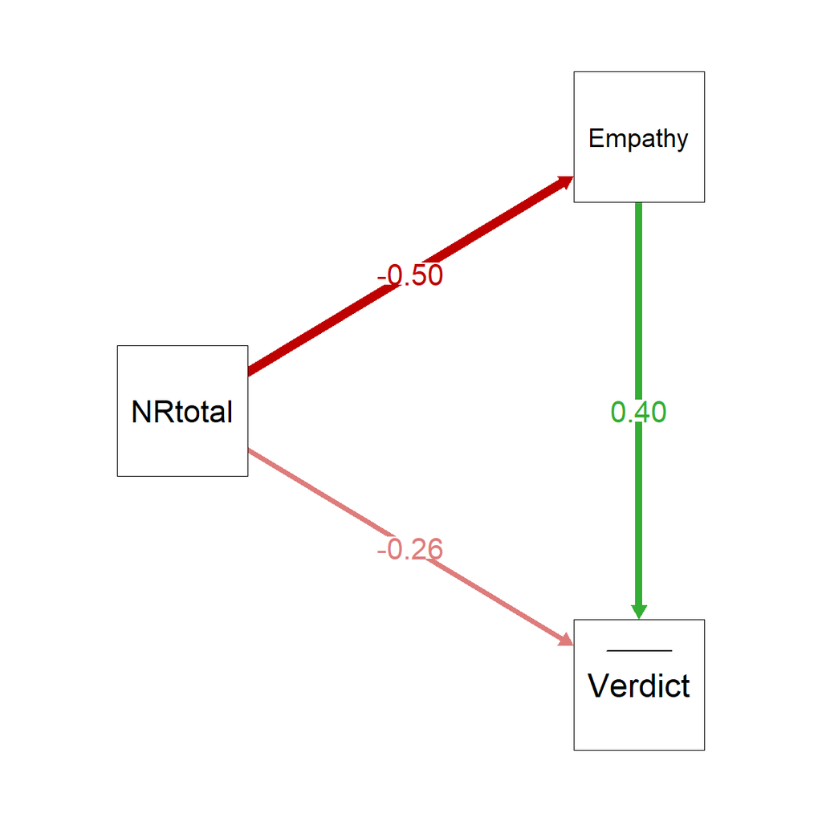

```r
semPaths(empmed, what="std",whatLabels = "std", sizeMan = 15, sizeInt = 15, sizeLat = 15,edge.label.cex=1.5, rotation=2, style = "lisrel", intercepts = F, residuals = F, nCharNodes=0)
```

```r
summary(empmed, standardize = TRUE, rsquare = TRUE)
```

```
## lavaan 0.6-11 ended normally after 19 iterations
##
##   Estimator                                       DWLS
##   Optimization method                           NLMINB
##   Number of model parameters                         6
##
##   Number of observations                           347
##
## Model Test User Model:
##
##   Test statistic                                 0.000
##   Degrees of freedom                                 0
##
## Parameter Estimates:
##
##   Standard errors                            Bootstrap
##   Number of requested bootstrap draws             5000
##   Number of successful bootstrap draws            5000
##
## Regressions:
##                    Estimate  Std.Err  z-value  P(>|z|)   Std.lv  Std.all
##   Verdict ~
##     NRtotal    (c)   -0.082    0.028   -2.921    0.003   -0.082   -0.259
##   Empathy ~
##     NRtotal    (a)   -0.152    0.014  -10.943    0.000   -0.152   -0.503
##   Verdict ~
##     Empathy    (b)    0.420    0.063    6.664    0.000    0.420    0.401
##
## Intercepts:
##                    Estimate  Std.Err  z-value  P(>|z|)   Std.lv  Std.all
##    .Verdict           0.000                               0.000    0.000
##    .Empathy           4.701    0.099   47.696    0.000    4.701    4.370
##
## Thresholds:
##                    Estimate  Std.Err  z-value  P(>|z|)   Std.lv  Std.all
##     Verdict|t1        0.714    0.353    2.024    0.043    0.714    0.633
##
## Variances:
##                    Estimate  Std.Err  z-value  P(>|z|)   Std.lv  Std.all
##    .Verdict           0.847                               0.847    0.667
##    .Empathy           0.864    0.056   15.545    0.000    0.864    0.747
##
## Scales y*:
##                    Estimate  Std.Err  z-value  P(>|z|)   Std.lv  Std.all
##     Verdict           1.000                               1.000    1.000
##
## R-Square:
##                    Estimate
##     Verdict           0.333
##     Empathy           0.253
##
## Defined Parameters:
##                    Estimate  Std.Err  z-value  P(>|z|)   Std.lv  Std.all
##     direct           -0.082    0.028   -2.925    0.003   -0.082   -0.259
##     indirect         -0.064    0.011   -5.655    0.000   -0.064   -0.202
##     total            -0.146    0.027   -5.308    0.000   -0.146   -0.461
```

```r
parameterestimates(empmed, standardized = TRUE, boot.ci.type = "bca.simple")
```

```
##         lhs  op     rhs    label    est    se       z pvalue ci.lower ci.upper
## 1   Verdict   ~ NRtotal        c -0.082 0.028  -2.921  0.003   -0.139   -0.032
## 2   Empathy   ~ NRtotal        a -0.152 0.014 -10.943  0.000   -0.181   -0.126
## 3   Verdict   ~ Empathy        b  0.420 0.063   6.664  0.000    0.293    0.542
## 4   Verdict   |      t1           0.714 0.353   2.024  0.043    0.016    1.397
## 5   Verdict  ~~ Verdict           0.847 0.000      NA     NA    0.847    0.847
## 6   Empathy  ~~ Empathy           0.864 0.056  15.545  0.000    0.762    0.984
## 7   NRtotal  ~~ NRtotal          12.707 0.000      NA     NA   12.707   12.707
## 8   Verdict ~*~ Verdict           1.000 0.000      NA     NA    1.000    1.000
## 9   Verdict  ~1                   0.000 0.000      NA     NA    0.000    0.000
## 10  Empathy  ~1                   4.701 0.099  47.696  0.000    4.512    4.894
## 11  NRtotal  ~1                   6.513 0.000      NA     NA    6.513    6.513
## 12   direct  :=       c   direct -0.082 0.028  -2.925  0.003   -0.139   -0.032
## 13 indirect  :=     a*b indirect -0.064 0.011  -5.655  0.000   -0.087   -0.043
## 14    total  := c+(a*b)    total -0.146 0.027  -5.308  0.000   -0.204   -0.098
##    std.lv std.all std.nox
## 1  -0.082  -0.259  -0.073
## 2  -0.152  -0.503  -0.141
## 3   0.420   0.401   0.401
## 4   0.714   0.633   0.633
## 5   0.847   0.667   0.667
## 6   0.864   0.747   0.747
## 7  12.707   1.000  12.707
## 8   1.000   1.000   1.000
## 9   0.000   0.000   0.000
## 10  4.701   4.370   4.370
## 11  6.513   1.827   6.513
## 12 -0.082  -0.259  -0.073
## 13 -0.064  -0.202  -0.057
## 14 -0.146  -0.461  -0.129
```

# CFA

```r
LIcfa<-'
LI=~1*LI1+LI2+LI3+LI4+LI5'
LIfit<-cfa(LIcfa, finaldata)
summary(LIfit, fit.measures=T)
```

```
## lavaan 0.6-11 ended normally after 23 iterations
##
##   Estimator                                         ML
##   Optimization method                           NLMINB
##   Number of model parameters                        10
##
##   Number of observations                           347
##
## Model Test User Model:
##
##   Test statistic                                11.043
##   Degrees of freedom                                 5
##   P-value (Chi-square)                           0.051
##
## Model Test Baseline Model:
##
##   Test statistic                              1464.671
##   Degrees of freedom                                10
##   P-value                                        0.000
##
## User Model versus Baseline Model:
##
##   Comparative Fit Index (CFI)                    0.996
##   Tucker-Lewis Index (TLI)                       0.992
##
## Loglikelihood and Information Criteria:
##
##   Loglikelihood user model (H0)              -2613.196
##   Loglikelihood unrestricted model (H1)      -2607.675
##
##   Akaike (AIC)                                5246.393
##   Bayesian (BIC)                              5284.886
##   Sample-size adjusted Bayesian (BIC)         5253.163
##
## Root Mean Square Error of Approximation:
##
##   RMSEA                                          0.059
##   90 Percent confidence interval - lower         0.000
##   90 Percent confidence interval - upper         0.107
##   P-value RMSEA <= 0.05                          0.317
```

[output cut: 13 more lines]

```
##   LI =~
##     LI1               1.000
##     LI2               1.018    0.043   23.874    0.000
##     LI3               1.024    0.033   31.109    0.000
##     LI4               0.710    0.038   18.724    0.000
##     LI5               0.882    0.046   19.004    0.000
##
## Variances:
##                    Estimate  Std.Err  z-value  P(>|z|)
##    .LI1               0.483    0.050    9.600    0.000
##    .LI2               0.872    0.077   11.252    0.000
##    .LI3               0.244    0.039    6.319    0.000
##    .LI4               0.853    0.070   12.254    0.000
##    .LI5               1.268    0.104   12.216    0.000
##     LI                2.340    0.214   10.938    0.000
```

```r
LIcfa2<-'
LI=~1*LI1+LI2+LI3+LI4+LI5+LI6'
LIfit2<-cfa(LIcfa2, finaldata)
summary(LIfit2, fit.measures=T)
```

```
## lavaan 0.6-11 ended normally after 25 iterations
##
##   Estimator                                         ML
##   Optimization method                           NLMINB
##   Number of model parameters                        12
##
##   Number of observations                           347
##
## Model Test User Model:
##
##   Test statistic                                66.778
##   Degrees of freedom                                 9
##   P-value (Chi-square)                           0.000
##
## Model Test Baseline Model:
##
##   Test statistic                              1728.758
##   Degrees of freedom                                15
##   P-value                                        0.000
##
## User Model versus Baseline Model:
##
##   Comparative Fit Index (CFI)                    0.966
##   Tucker-Lewis Index (TLI)                       0.944
##
## Loglikelihood and Information Criteria:
##
##   Loglikelihood user model (H0)              -3087.563
##   Loglikelihood unrestricted model (H1)      -3054.174
##
##   Akaike (AIC)                                6199.126
##   Bayesian (BIC)                              6245.318
##   Sample-size adjusted Bayesian (BIC)         6207.250
##
## Root Mean Square Error of Approximation:
##
##   RMSEA                                          0.136
##   90 Percent confidence interval - lower         0.107
##   90 Percent confidence interval - upper         0.167
##   P-value RMSEA <= 0.05                          0.000
```

[output cut: 15 more lines]

```
##     LI2               1.023    0.043   23.926    0.000
##     LI3               1.019    0.033   30.537    0.000
##     LI4               0.722    0.038   19.233    0.000
##     LI5               0.891    0.046   19.225    0.000
##     LI6               0.580    0.037   15.823    0.000
##
## Variances:
##                    Estimate  Std.Err  z-value  P(>|z|)
##    .LI1               0.491    0.050    9.792    0.000
##    .LI2               0.859    0.076   11.228    0.000
##    .LI3               0.278    0.039    7.213    0.000
##    .LI4               0.815    0.067   12.174    0.000
##    .LI5               1.240    0.102   12.175    0.000
##    .LI6               0.859    0.068   12.569    0.000
##     LI                2.332    0.214   10.913    0.000
```

```r
SAcfa<-'
SA=~1*SA1+SA2+SA3+SA4'
SAfit<-cfa(SAcfa, finaldata)
summary(SAfit, fit.measures=T)
```

```
## lavaan 0.6-11 ended normally after 21 iterations
##
##   Estimator                                         ML
##   Optimization method                           NLMINB
##   Number of model parameters                         8
##
##   Number of observations                           347
##
## Model Test User Model:
##
##   Test statistic                                11.742
##   Degrees of freedom                                 2
##   P-value (Chi-square)                           0.003
##
## Model Test Baseline Model:
##
##   Test statistic                               658.517
##   Degrees of freedom                                 6
##   P-value                                        0.000
##
## User Model versus Baseline Model:
##
##   Comparative Fit Index (CFI)                    0.985
##   Tucker-Lewis Index (TLI)                       0.955
##
## Loglikelihood and Information Criteria:
##
##   Loglikelihood user model (H0)              -2141.459
##   Loglikelihood unrestricted model (H1)      -2135.588
##
##   Akaike (AIC)                                4298.919
##   Bayesian (BIC)                              4329.714
##   Sample-size adjusted Bayesian (BIC)         4304.335
##
## Root Mean Square Error of Approximation:
##
##   RMSEA                                          0.118
##   90 Percent confidence interval - lower         0.059
##   90 Percent confidence interval - upper         0.188
##   P-value RMSEA <= 0.05                          0.030
```

[output cut: 11 more lines]

```
## Latent Variables:
##                    Estimate  Std.Err  z-value  P(>|z|)
##   SA =~
##     SA1               1.000
##     SA2               1.165    0.092   12.664    0.000
##     SA3               0.826    0.070   11.793    0.000
##     SA4               1.399    0.119   11.751    0.000
##
## Variances:
##                    Estimate  Std.Err  z-value  P(>|z|)
##    .SA1               1.575    0.131   12.065    0.000
##    .SA2               0.307    0.056    5.460    0.000
##    .SA3               0.450    0.044   10.248    0.000
##    .SA4               1.324    0.128   10.337    0.000
##     SA                1.036    0.167    6.221    0.000
```

```r
NRcfa<-'
NR=~1*NR1+NR2+NR4+NR5'
NRfit<-cfa(NRcfa, finaldata)
summary(NRfit, fit.measures=T)
```

```
## lavaan 0.6-11 ended normally after 27 iterations
##
##   Estimator                                         ML
##   Optimization method                           NLMINB
##   Number of model parameters                         8
##
##   Number of observations                           347
##
## Model Test User Model:
##
##   Test statistic                                12.756
##   Degrees of freedom                                 2
##   P-value (Chi-square)                           0.002
##
## Model Test Baseline Model:
##
##   Test statistic                               329.420
##   Degrees of freedom                                 6
##   P-value                                        0.000
##
## User Model versus Baseline Model:
##
##   Comparative Fit Index (CFI)                    0.967
##   Tucker-Lewis Index (TLI)                       0.900
##
## Loglikelihood and Information Criteria:
##
##   Loglikelihood user model (H0)              -1810.726
##   Loglikelihood unrestricted model (H1)      -1804.348
##
##   Akaike (AIC)                                3637.452
##   Bayesian (BIC)                              3668.247
##   Sample-size adjusted Bayesian (BIC)         3642.868
##
## Root Mean Square Error of Approximation:
##
##   RMSEA                                          0.124
##   90 Percent confidence interval - lower         0.065
##   90 Percent confidence interval - upper         0.194
##   P-value RMSEA <= 0.05                          0.021
```

[output cut: 11 more lines]

```
## Latent Variables:
##                    Estimate  Std.Err  z-value  P(>|z|)
##   NR =~
##     NR1               1.000
##     NR2               0.959    0.094   10.173    0.000
##     NR4               0.243    0.030    8.124    0.000
##     NR5               1.175    0.134    8.769    0.000
##
## Variances:
##                    Estimate  Std.Err  z-value  P(>|z|)
##    .NR1               0.881    0.092    9.538    0.000
##    .NR2               0.286    0.060    4.749    0.000
##    .NR4               0.129    0.011   11.935    0.000
##    .NR5               2.378    0.206   11.551    0.000
##     NR                0.775    0.124    6.248    0.000
```

```r
CFAmodel<-'
LI=~1*LI1+LI2+LI3+LI4+LI5+LI6
SA=~1*SA1+SA2+SA3+SA4
NR=~1*NR1+NR2+NR4+NR5
SA~~LI+NR
LI~~NR'
CFAfit<-cfa(CFAmodel, finaldata)
summary(CFAfit, fit.measures=T)
```

```
## lavaan 0.6-11 ended normally after 44 iterations
##
##   Estimator                                         ML
##   Optimization method                           NLMINB
##   Number of model parameters                        31
##
##   Number of observations                           347
##
## Model Test User Model:
##
##   Test statistic                               362.109
##   Degrees of freedom                                74
##   P-value (Chi-square)                           0.000
##
## Model Test Baseline Model:
##
##   Test statistic                              3406.567
##   Degrees of freedom                                91
##   P-value                                        0.000
##
## User Model versus Baseline Model:
##
##   Comparative Fit Index (CFI)                    0.913
##   Tucker-Lewis Index (TLI)                       0.893
##
## Loglikelihood and Information Criteria:
##
##   Loglikelihood user model (H0)              -6830.229
##   Loglikelihood unrestricted model (H1)      -6649.175
##
##   Akaike (AIC)                               13722.458
##   Bayesian (BIC)                             13841.787
##   Sample-size adjusted Bayesian (BIC)        13743.446
##
## Root Mean Square Error of Approximation:
##
##   RMSEA                                          0.106
##   90 Percent confidence interval - lower         0.095
##   90 Percent confidence interval - upper         0.117
##   P-value RMSEA <= 0.05                          0.000
```

[output cut: 44 more lines]

```
##    .LI3               0.315    0.039    8.088    0.000
##    .LI4               0.776    0.064   12.105    0.000
##    .LI5               1.227    0.101   12.172    0.000
##    .LI6               0.819    0.065   12.513    0.000
##    .SA1               1.360    0.116   11.682    0.000
##    .SA2               0.500    0.055    9.166    0.000
##    .SA3               0.428    0.041   10.365    0.000
##    .SA4               1.235    0.119   10.352    0.000
##    .NR1               0.850    0.080   10.647    0.000
##    .NR2               0.431    0.045    9.618    0.000
##    .NR4               0.137    0.011   12.452    0.000
##    .NR5               1.889    0.172   10.987    0.000
##     LI                2.314    0.213   10.845    0.000
##     SA                1.251    0.178    7.045    0.000
##     NR                0.807    0.118    6.852    0.000
```

```r
modificationindices(CFAfit, sort=T)
```

```
##     lhs op rhs     mi    epc sepc.lv sepc.all sepc.nox
## 42   LI =~ NR5 36.507  0.683   1.039    0.560    0.560
## 100 LI4 ~~ LI6 35.535  0.275   0.275    0.345    0.345
## 36   LI =~ SA2 32.205 -0.326  -0.496   -0.379   -0.379
## 58   NR =~ LI6 28.437  0.586   0.526    0.410    0.410
## 56   NR =~ LI4 25.652  0.552   0.496    0.348    0.348
## 48   SA =~ LI6 24.353  0.384   0.430    0.335    0.335
## 35   LI =~ SA1 23.953  0.375   0.570    0.353    0.353
## 60   NR =~ SA2 22.891 -0.626  -0.563   -0.430   -0.430
## 124 LI6 ~~ NR4 22.487  0.089   0.089    0.267    0.267
## 151 NR2 ~~ NR4 22.446  0.077   0.077    0.316    0.316
## 133 SA2 ~~ SA3 22.342  0.195   0.195    0.421    0.421
## 64  LI1 ~~ LI3 21.352  0.194   0.194    0.484    0.484
## 59   NR =~ SA1 20.206  0.779   0.700    0.433    0.433
## 139 SA3 ~~ SA4 20.125 -0.255  -0.255   -0.351   -0.351
```

[output cut: 105 more lines]

```r
CFAmodel1<-'
LI=~1*LI1+LI2+LI3+LI4+LI5
SA=~1*SA1+SA2+SA3+SA4
NR=~1*NR1+NR2+NR4+NR5
SA~~LI+NR
LI~~NR
'
CFAfit1<-cfa(CFAmodel1, finaldata)
summary(CFAfit1, fit.measures=T)
```

```
## lavaan 0.6-11 ended normally after 42 iterations
##
##   Estimator                                         ML
##   Optimization method                           NLMINB
##   Number of model parameters                        29
##
##   Number of observations                           347
##
## Model Test User Model:
##
##   Test statistic                               272.936
##   Degrees of freedom                                62
##   P-value (Chi-square)                           0.000
##
## Model Test Baseline Model:
##
##   Test statistic                              3094.812
##   Degrees of freedom                                78
##   P-value                                        0.000
##
## User Model versus Baseline Model:
##
##   Comparative Fit Index (CFI)                    0.930
##   Tucker-Lewis Index (TLI)                       0.912
##
## Loglikelihood and Information Criteria:
##
##   Loglikelihood user model (H0)              -6362.978
##   Loglikelihood unrestricted model (H1)      -6226.509
##
##   Akaike (AIC)                               12783.955
##   Bayesian (BIC)                             12895.585
##   Sample-size adjusted Bayesian (BIC)        12803.589
##
## Root Mean Square Error of Approximation:
##
##   RMSEA                                          0.099
##   90 Percent confidence interval - lower         0.087
##   90 Percent confidence interval - upper         0.111
##   P-value RMSEA <= 0.05                          0.000
```

[output cut: 42 more lines]

```
##    .LI2               0.865    0.077   11.291    0.000
##    .LI3               0.272    0.038    7.208    0.000
##    .LI4               0.818    0.067   12.203    0.000
##    .LI5               1.250    0.102   12.211    0.000
##    .SA1               1.362    0.117   11.679    0.000
##    .SA2               0.498    0.055    9.116    0.000
##    .SA3               0.428    0.041   10.353    0.000
##    .SA4               1.236    0.120   10.341    0.000
##    .NR1               0.845    0.080   10.583    0.000
##    .NR2               0.429    0.045    9.547    0.000
##    .NR4               0.137    0.011   12.450    0.000
##    .NR5               1.899    0.173   10.988    0.000
##     LI                2.337    0.214   10.938    0.000
##     SA                1.249    0.177    7.036    0.000
##     NR                0.812    0.118    6.872    0.000
```

```r
modificationindices(CFAfit1, sort=T)
```

```
##     lhs op rhs     mi    epc sepc.lv sepc.all sepc.nox
## 40   LI =~ NR5 36.482  0.643   0.982    0.529    0.529
## 53   NR =~ LI4 32.858  0.609   0.549    0.385    0.385
## 34   LI =~ SA2 31.132 -0.307  -0.469   -0.358   -0.358
## 33   LI =~ SA1 23.970  0.361   0.552    0.341    0.341
## 134 NR2 ~~ NR4 22.926  0.078   0.078    0.321    0.321
## 56   NR =~ SA2 22.675 -0.619  -0.558   -0.426   -0.426
## 116 SA2 ~~ SA3 22.253  0.195   0.195    0.423    0.423
## 122 SA3 ~~ SA4 20.044 -0.256  -0.256   -0.352   -0.352
## 55   NR =~ SA1 20.036  0.771   0.695    0.430    0.430
## 44   SA =~ LI4 18.244  0.327   0.366    0.256    0.256
## 99  LI4 ~~ NR4 15.588  0.075   0.075    0.225    0.225
## 36   LI =~ SA4 14.588  0.298   0.455    0.249    0.249
## 117 SA2 ~~ SA4 14.573  0.269   0.269    0.343    0.343
## 123 SA3 ~~ NR1 10.812  0.130   0.130    0.216    0.216
```

[output cut: 90 more lines]

# SEM

```r
semdata <- finaldata %>%
   mutate(Scaleconf = Confidence / 10)
```

```r
SEMmodel<-'
#measurement model
LI=~1*LI1+LI2+LI3+LI4+LI5
SA=~1*SA1+SA2+SA3+SA4
NR=~1*NR1+NR2+NR4+NR5


#Regression equations
Verdict~b*Credibility+e*Responsibility+y*Empathy
Verdict~c*LI + f*SA + z*NR
Credibility~Empathy
Credibility~a*LI
Responsibility~d*SA
Empathy~x*NR

#direct & indirect paths
indirectcred := a*b
totalcred := c + (a*b)

indirectresp := d*e
totalresp := f + (d*e)

indirectemp := x*y
totalemp := z + (x*y)

#Estimating endogenous variables covariance
SA~~LI+NR
LI~~NR

'

fitSEMmodel<-sem(SEMmodel, data=semdata, ordered = c("Verdict"))
```

```r
set.seed(2021)
summary(fitSEMmodel, fit.measures=TRUE)
```

```
## lavaan 0.6-11 ended normally after 98 iterations
##
##   Estimator                                       DWLS
##   Optimization method                           NLMINB
##   Number of model parameters                        59
##
##   Number of observations                           347
##
## Model Test User Model:
##                                               Standard      Robust
##   Test Statistic                               117.390     490.380
##   Degrees of freedom                               110         110
##   P-value (Chi-square)                           0.297       0.000
##   Scaling correction factor                                  0.272
##   Shift parameter                                           59.134
##        simple second-order correction
##
## Model Test Baseline Model:
##
##   Test statistic                              5836.228    1192.581
##   Degrees of freedom                               136         136
##   P-value                                        0.000       0.000
##   Scaling correction factor                                  5.395
##
## User Model versus Baseline Model:
##
##   Comparative Fit Index (CFI)                    0.999       0.640
##   Tucker-Lewis Index (TLI)                       0.998       0.555
##
##   Robust Comparative Fit Index (CFI)                            NA
##   Robust Tucker-Lewis Index (TLI)                               NA
##
## Root Mean Square Error of Approximation:
##
##   RMSEA                                          0.014       0.100
##   90 Percent confidence interval - lower         0.000       0.091
##   90 Percent confidence interval - upper         0.031       0.109
##   P-value RMSEA <= 0.05                          1.000       0.000
##
##   Robust RMSEA                                                  NA
```

[output cut: 105 more lines]

```
##     SA                1.486    0.306    4.857    0.000
##     NR                0.669    0.119    5.642    0.000
##
## Scales y*:
##                    Estimate  Std.Err  z-value  P(>|z|)
##     Verdict           1.000
##
## Defined Parameters:
##                    Estimate  Std.Err  z-value  P(>|z|)
##     indirectcred     -0.091    0.016   -5.614    0.000
##     totalcred        -0.210    0.089   -2.356    0.018
##     indirectresp     -0.206    0.071   -2.890    0.004
##     totalresp         0.220    0.214    1.026    0.305
##     indirectemp      -0.147    0.082   -1.798    0.072
##     totalemp         -0.516    0.315   -1.640    0.101
```

```r
parameterestimates(fitSEMmodel,standardized = TRUE, rsquare=TRUE, output="text")
```

```
##
## Latent Variables:
##                    Estimate  Std.Err  z-value  P(>|z|) ci.lower ci.upper
##   LI =~
##     LI1               1.000                               1.000    1.000
##     LI2               1.035    0.070   14.880    0.000    0.899    1.171
##     LI3               1.016    0.054   18.756    0.000    0.910    1.122
##     LI4               0.828    0.061   13.545    0.000    0.708    0.948
##     LI5               0.914    0.077   11.805    0.000    0.762    1.066
##   SA =~
##     SA1               1.000                               1.000    1.000
##     SA2               0.783    0.084    9.280    0.000    0.618    0.948
##     SA3               0.664    0.086    7.693    0.000    0.495    0.833
##     SA4               1.137    0.151    7.547    0.000    0.842    1.432
##   NR =~
##     NR1               1.000                               1.000    1.000
##     NR2               0.851    0.088    9.724    0.000    0.680    1.023
##     NR4               0.214    0.028    7.759    0.000    0.160    0.268
##     NR5               1.609    0.197    8.166    0.000    1.223    1.995
##    Std.lv  Std.all
##
##     1.475    0.878
##     1.527    0.841
##     1.498    0.912
##     1.222    0.857
##     1.348    0.767
##
##     1.219    0.754
##     0.955    0.729
##     0.809    0.752
##     1.386    0.757
##
##     0.818    0.636
##     0.696    0.697
##     0.175    0.419
##     1.316    0.709
##
## Regressions:
##                    Estimate  Std.Err  z-value  P(>|z|) ci.lower ci.upper
##   Verdict ~
```

[output cut: 165 more lines]

```
## Defined Parameters:
##                    Estimate  Std.Err  z-value  P(>|z|) ci.lower ci.upper
##     indirectcred     -0.091    0.016   -5.614    0.000   -0.123   -0.059
##     totalcred        -0.210    0.089   -2.356    0.018   -0.384   -0.035
##     indirectresp     -0.206    0.071   -2.890    0.004   -0.345   -0.066
##     totalresp         0.220    0.214    1.026    0.305   -0.200    0.640
##     indirectemp      -0.147    0.082   -1.798    0.072   -0.307    0.013
##     totalemp         -0.516    0.315   -1.640    0.101   -1.133    0.101
##    Std.lv  Std.all
##    -0.135   -0.135
##    -0.310   -0.310
##    -0.251   -0.251
##     0.268    0.268
##    -0.120   -0.120
##    -0.422   -0.422
```

```r
modificationindices(fitSEMmodel, sort=TRUE)
```

```
##                lhs op            rhs     mi    epc sepc.lv sepc.all sepc.nox
## 216            NR2 ~~            NR4 29.989  0.096   0.096    0.354    0.354
## 266             NR  ~        Empathy 24.310  0.454   0.555    0.609    0.609
## 263             NR  ~        Verdict 17.082  0.591   0.723    0.723    0.723
## 250        Empathy  ~             SA 15.552 -1.244  -1.517   -1.382   -1.382
## 264             NR  ~    Credibility 12.960  0.183   0.224    0.306    0.306
## 249        Empathy  ~             LI 12.490 -0.428  -0.631   -0.575   -0.575
## 246        Empathy  ~        Verdict 11.568  1.221   1.221    1.112    1.112
## 248        Empathy  ~ Responsibility 10.111 -0.318  -0.318   -0.537   -0.537
## 247        Empathy  ~    Credibility  9.367  0.465   0.465    0.580    0.580
## 241 Responsibility  ~        Verdict  9.121 -1.215  -1.215   -0.655   -0.655
## 219            NR2 ~~    Credibility  8.659  0.201   0.201    0.257    0.257
## 251             LI  ~        Verdict  8.460 -0.709  -0.480   -0.480   -0.480
## 95              NR =~            LI4  8.209  1.051   0.860    0.603    0.603
## 80              LI =~            NR2  7.814 -0.303  -0.447   -0.448   -0.448
```

[output cut: 171 more lines]

## model A - remove NR direct path

```r
SEMmodelA<-'
#measurement model
LI=~1*LI1+LI2+LI3+LI4+LI5
SA=~1*SA1+SA2+SA3+SA4
NR=~1*NR1+NR2+NR4+NR5


#Regression equations
Verdict~b*Credibility+e*Responsibility+y*Empathy
Verdict~c*LI + f*SA
Credibility~Empathy
Credibility~a*LI
Responsibility~d*SA
Empathy~x*NR

#direct & indirect paths
indirectcred := a*b
totalcred := c + (a*b)

indirectresp := d*e
totalresp := f + (d*e)

indirectemp := x*y


#Estimating endogenous variables covariance
SA~~LI+NR
LI~~NR

'

fitSEMmodelA<-sem(SEMmodelA, data=semdata, ordered = c("Verdict"))
set.seed(2021)
summary(fitSEMmodelA, fit.measures=TRUE,standardized = TRUE)
```

```
## lavaan 0.6-11 ended normally after 90 iterations
##
##   Estimator                                       DWLS
##   Optimization method                           NLMINB
##   Number of model parameters                        58
##
##   Number of observations                           347
##
## Model Test User Model:
##                                               Standard      Robust
##   Test Statistic                               117.989     475.003
##   Degrees of freedom                               111         111
##   P-value (Chi-square)                           0.307       0.000
##   Scaling correction factor                                  0.284
##   Shift parameter                                           60.196
##        simple second-order correction
##
## Model Test Baseline Model:
##
##   Test statistic                              5836.228    1192.581
##   Degrees of freedom                               136         136
##   P-value                                        0.000       0.000
##   Scaling correction factor                                  5.395
##
## User Model versus Baseline Model:
##
##   Comparative Fit Index (CFI)                    0.999       0.655
##   Tucker-Lewis Index (TLI)                       0.998       0.578
##
##   Robust Comparative Fit Index (CFI)                            NA
##   Robust Tucker-Lewis Index (TLI)                               NA
##
## Root Mean Square Error of Approximation:
##
##   RMSEA                                          0.013       0.097
##   90 Percent confidence interval - lower         0.000       0.088
##   90 Percent confidence interval - upper         0.031       0.106
##   P-value RMSEA <= 0.05                          1.000       0.000
##
##   Robust RMSEA                                                  NA
```

[output cut: 103 more lines]

```
##     LI                2.173    0.306    7.099    0.000    1.000    1.000
##     SA                1.487    0.306    4.856    0.000    1.000    1.000
##     NR                0.674    0.120    5.618    0.000    1.000    1.000
##
## Scales y*:
##                    Estimate  Std.Err  z-value  P(>|z|)   Std.lv  Std.all
##     Verdict           1.000                               1.000    1.000
##
## Defined Parameters:
##                    Estimate  Std.Err  z-value  P(>|z|)   Std.lv  Std.all
##     indirectcred     -0.089    0.016   -5.508    0.000   -0.132   -0.132
##     totalcred        -0.231    0.083   -2.767    0.006   -0.340   -0.340
##     indirectresp     -0.189    0.072   -2.633    0.008   -0.230   -0.230
##     totalresp         0.036    0.118    0.305    0.760    0.044    0.044
##     indirectemp      -0.202    0.062   -3.265    0.001   -0.166   -0.166
```

```r
parameterestimates(fitSEMmodelA,standardized = TRUE)
```

```
##               lhs  op            rhs        label    est    se      z pvalue
## 1              LI  =~            LI1               1.000 0.000     NA     NA
## 2              LI  =~            LI2               1.035 0.070 14.880  0.000
## 3              LI  =~            LI3               1.015 0.054 18.748  0.000
## 4              LI  =~            LI4               0.828 0.061 13.544  0.000
## 5              LI  =~            LI5               0.914 0.077 11.803  0.000
## 6              SA  =~            SA1               1.000 0.000     NA     NA
## 7              SA  =~            SA2               0.783 0.084  9.281  0.000
## 8              SA  =~            SA3               0.664 0.086  7.691  0.000
## 9              SA  =~            SA4               1.137 0.151  7.545  0.000
## 10             NR  =~            NR1               1.000 0.000     NA     NA
## 11             NR  =~            NR2               0.851 0.088  9.718  0.000
## 12             NR  =~            NR4               0.214 0.028  7.758  0.000
## 13             NR  =~            NR5               1.607 0.197  8.166  0.000
## 14        Verdict   ~    Credibility            b  0.273 0.037  7.347  0.000
```

[output cut: 131 more lines]

```r
modificationindices(fitSEMmodelA, sort=TRUE)
```

```
##                lhs op            rhs     mi    epc sepc.lv sepc.all sepc.nox
## 214            NR2 ~~            NR4 29.260  0.095   0.095    0.351    0.351
## 265             NR  ~        Empathy 21.168  0.418   0.509    0.556    0.556
## 249        Empathy  ~             SA 13.602 -1.086  -1.324   -1.211   -1.211
## 248        Empathy  ~             LI 11.512 -0.406  -0.599   -0.547   -0.547
## 263             NR  ~    Credibility 10.666  0.161   0.196    0.269    0.269
## 240 Responsibility  ~        Verdict  9.694 -1.236  -1.236   -0.666   -0.666
## 247        Empathy  ~ Responsibility  9.481 -0.302  -0.302   -0.512   -0.512
## 246        Empathy  ~    Credibility  8.431  0.432   0.432    0.540    0.540
## 245        Empathy  ~        Verdict  8.291  0.794   0.794    0.725    0.725
## 93              NR =~            LI4  8.280  1.041   0.855    0.600    0.600
## 217            NR2 ~~    Credibility  8.264  0.196   0.196    0.251    0.251
## 78              LI =~            NR2  7.957 -0.307  -0.453   -0.453   -0.453
## 241 Responsibility  ~    Credibility  7.411 -0.410  -0.410   -0.302   -0.302
## 219            NR2 ~~        Empathy  7.034  0.177   0.177    0.308    0.308
```

[output cut: 173 more lines]

## model B - remove SA direct path

```r
SEMmodelB<-'
#measurement model
LI=~1*LI1+LI2+LI3+LI4+LI5
SA=~1*SA1+SA2+SA3+SA4
NR=~1*NR1+NR2+NR4+NR5


#Regression equations
Verdict~b*Credibility+e*Responsibility+y*Empathy
Verdict~c*LI
Credibility~Empathy
Credibility~a*LI
Responsibility~d*SA
Empathy~x*NR

#direct & indirect paths
indirectcred := a*b
totalcred := c + (a*b)

indirectresp := d*e

indirectemp := x*y


#Estimating endogenous variables covariance
SA~~LI+NR
LI~~NR

'

fitSEMmodelB<-sem(SEMmodelB, data=semdata, ordered = c("Verdict"))
set.seed(2021)
summary(fitSEMmodelB, fit.measures=TRUE,standardized = TRUE)
```

```
## lavaan 0.6-11 ended normally after 84 iterations
##
##   Estimator                                       DWLS
##   Optimization method                           NLMINB
##   Number of model parameters                        57
##
##   Number of observations                           347
##
## Model Test User Model:
##                                               Standard      Robust
##   Test Statistic                               119.075     463.332
##   Degrees of freedom                               112         112
##   P-value (Chi-square)                           0.306       0.000
##   Scaling correction factor                                  0.296
##   Shift parameter                                           61.156
##        simple second-order correction
##
## Model Test Baseline Model:
##
##   Test statistic                              5836.228    1192.581
##   Degrees of freedom                               136         136
##   P-value                                        0.000       0.000
##   Scaling correction factor                                  5.395
##
## User Model versus Baseline Model:
##
##   Comparative Fit Index (CFI)                    0.999       0.667
##   Tucker-Lewis Index (TLI)                       0.998       0.596
##
##   Robust Comparative Fit Index (CFI)                            NA
##   Robust Tucker-Lewis Index (TLI)                               NA
##
## Root Mean Square Error of Approximation:
##
##   RMSEA                                          0.014       0.095
##   90 Percent confidence interval - lower         0.000       0.086
##   90 Percent confidence interval - upper         0.031       0.104
##   P-value RMSEA <= 0.05                          1.000       0.000
##
##   Robust RMSEA                                                  NA
```

[output cut: 101 more lines]

```
##    .Empathy           0.664    0.062   10.796    0.000    0.664    0.549
##     LI                2.182    0.307    7.108    0.000    1.000    1.000
##     SA                1.473    0.304    4.837    0.000    1.000    1.000
##     NR                0.672    0.120    5.616    0.000    1.000    1.000
##
## Scales y*:
##                    Estimate  Std.Err  z-value  P(>|z|)   Std.lv  Std.all
##     Verdict           1.000                               1.000    1.000
##
## Defined Parameters:
##                    Estimate  Std.Err  z-value  P(>|z|)   Std.lv  Std.all
##     indirectcred     -0.093    0.017   -5.461    0.000   -0.138   -0.138
##     totalcred        -0.155    0.053   -2.917    0.004   -0.229   -0.229
##     indirectresp     -0.094    0.043   -2.163    0.031   -0.114   -0.114
##     indirectemp      -0.151    0.054   -2.824    0.005   -0.124   -0.124
```

```r
parameterestimates(fitSEMmodelB,standardized = TRUE)
```

```
##               lhs  op            rhs        label    est    se      z pvalue
## 1              LI  =~            LI1               1.000 0.000     NA     NA
## 2              LI  =~            LI2               1.035 0.070 14.885  0.000
## 3              LI  =~            LI3               1.016 0.054 18.751  0.000
## 4              LI  =~            LI4               0.828 0.061 13.545  0.000
## 5              LI  =~            LI5               0.913 0.077 11.804  0.000
## 6              SA  =~            SA1               1.000 0.000     NA     NA
## 7              SA  =~            SA2               0.782 0.084  9.280  0.000
## 8              SA  =~            SA3               0.663 0.086  7.691  0.000
## 9              SA  =~            SA4               1.137 0.151  7.544  0.000
## 10             NR  =~            NR1               1.000 0.000     NA     NA
## 11             NR  =~            NR2               0.851 0.088  9.721  0.000
## 12             NR  =~            NR4               0.214 0.028  7.757  0.000
## 13             NR  =~            NR5               1.608 0.197  8.165  0.000
## 14        Verdict   ~    Credibility            b  0.286 0.040  7.209  0.000
```

[output cut: 127 more lines]

```r
modificationindices(fitSEMmodelB, sort=TRUE)
```

```
##                lhs op            rhs     mi    epc sepc.lv sepc.all sepc.nox
## 212            NR2 ~~            NR4 29.538  0.096   0.096    0.352    0.352
## 264             NR  ~        Empathy 22.030  0.417   0.509    0.560    0.560
## 248        Empathy  ~             SA 13.547 -1.140  -1.384   -1.258   -1.258
## 247        Empathy  ~             LI 12.592 -0.420  -0.621   -0.564   -0.564
## 262             NR  ~    Credibility 10.779  0.160   0.195    0.266    0.266
## 246        Empathy  ~ Responsibility 10.166 -0.304  -0.304   -0.516   -0.516
## 245        Empathy  ~    Credibility  9.328  0.450   0.450    0.560    0.560
## 91              NR =~            LI4  8.353  1.052   0.862    0.605    0.605
## 215            NR2 ~~    Credibility  8.324  0.196   0.196    0.251    0.251
## 240 Responsibility  ~    Credibility  8.293 -0.420  -0.420   -0.307   -0.307
## 76              LI =~            NR2  8.013 -0.306  -0.452   -0.452   -0.452
## 252             LI  ~        Empathy  7.998 -0.348  -0.235   -0.259   -0.259
## 244        Empathy  ~        Verdict  7.545  0.668   0.668    0.607    0.607
## 239 Responsibility  ~        Verdict  7.489 -0.769  -0.769   -0.411   -0.411
```

[output cut: 175 more lines]

## model 1- no direct paths

```r
SEMmodel1<-'
#measurement model
LI=~1*LI1+LI2+LI3+LI4+LI5
SA=~1*SA1+SA2+SA3+SA4
NR=~1*NR1+NR2+NR4+NR5


#regression equations
Verdict~b*Credibility+e*Responsibility+y*Empathy
Credibility~Empathy
Credibility~a*LI
Responsibility~d*SA
Empathy~x*NR


#Indirect pathways
indirectcred := a*b
indirectresp := d*e
indirectemp := x*y


#covariance
SA~~LI+NR
LI~~NR

'
fitSEMmodel1<-sem(SEMmodel1, data=semdata, ordered = c("Verdict"))


set.seed(2021)
summary(fitSEMmodel1, fit.measures=TRUE,standardized = TRUE)
```

```
## lavaan 0.6-11 ended normally after 82 iterations
##
##   Estimator                                       DWLS
##   Optimization method                           NLMINB
##   Number of model parameters                        56
##
##   Number of observations                           347
##
## Model Test User Model:
##                                               Standard      Robust
##   Test Statistic                               119.711     460.270
##   Degrees of freedom                               113         113
##   P-value (Chi-square)                           0.315       0.000
##   Scaling correction factor                                  0.300
##   Shift parameter                                           61.165
##        simple second-order correction
##
## Model Test Baseline Model:
##
##   Test statistic                              5836.228    1192.581
##   Degrees of freedom                               136         136
##   P-value                                        0.000       0.000
##   Scaling correction factor                                  5.395
##
## User Model versus Baseline Model:
##
##   Comparative Fit Index (CFI)                    0.999       0.671
##   Tucker-Lewis Index (TLI)                       0.999       0.604
##
##   Robust Comparative Fit Index (CFI)                            NA
##   Robust Tucker-Lewis Index (TLI)                               NA
##
## Root Mean Square Error of Approximation:
##
##   RMSEA                                          0.013       0.094
##   90 Percent confidence interval - lower         0.000       0.085
##   90 Percent confidence interval - upper         0.031       0.103
##   P-value RMSEA <= 0.05                          1.000       0.000
##
##   Robust RMSEA                                                  NA
```

[output cut: 99 more lines]

```
##    .Responsibility    1.512    0.204    7.420    0.000    1.512    0.437
##    .Empathy           0.656    0.062   10.505    0.000    0.656    0.545
##     LI                2.184    0.307    7.114    0.000    1.000    1.000
##     SA                1.469    0.304    4.831    0.000    1.000    1.000
##     NR                0.673    0.120    5.613    0.000    1.000    1.000
##
## Scales y*:
##                    Estimate  Std.Err  z-value  P(>|z|)   Std.lv  Std.all
##     Verdict           1.000                               1.000    1.000
##
## Defined Parameters:
##                    Estimate  Std.Err  z-value  P(>|z|)   Std.lv  Std.all
##     indirectcred     -0.106    0.019   -5.646    0.000   -0.157   -0.157
##     indirectresp     -0.133    0.040   -3.278    0.001   -0.161   -0.161
##     indirectemp      -0.170    0.054   -3.166    0.002   -0.139   -0.139
```

```r
parameterestimates(fitSEMmodel1,standardized = TRUE)
```

```
##               lhs  op            rhs        label    est    se      z pvalue
## 1              LI  =~            LI1               1.000 0.000     NA     NA
## 2              LI  =~            LI2               1.035 0.070 14.892  0.000
## 3              LI  =~            LI3               1.016 0.054 18.760  0.000
## 4              LI  =~            LI4               0.828 0.061 13.551  0.000
## 5              LI  =~            LI5               0.913 0.077 11.810  0.000
## 6              SA  =~            SA1               1.000 0.000     NA     NA
## 7              SA  =~            SA2               0.782 0.084  9.281  0.000
## 8              SA  =~            SA3               0.663 0.086  7.692  0.000
## 9              SA  =~            SA4               1.137 0.151  7.544  0.000
## 10             NR  =~            NR1               1.000 0.000     NA     NA
## 11             NR  =~            NR2               0.851 0.088  9.719  0.000
## 12             NR  =~            NR4               0.214 0.028  7.755  0.000
## 13             NR  =~            NR5               1.609 0.197  8.164  0.000
## 14        Verdict   ~    Credibility            b  0.310 0.036  8.609  0.000
```

[output cut: 123 more lines]

```r
modificationindices(fitSEMmodel1, sort=TRUE)
```

```
##                lhs op            rhs     mi    epc sepc.lv sepc.all sepc.nox
## 210            NR2 ~~            NR4 29.443  0.095   0.095    0.352    0.352
## 263             NR  ~        Empathy 21.749  0.421   0.513    0.563    0.563
## 246        Empathy  ~             LI 13.539 -0.433  -0.640   -0.584   -0.584
## 247        Empathy  ~             SA 12.947 -1.105  -1.339   -1.220   -1.220
## 244        Empathy  ~    Credibility 10.289  0.461   0.461    0.571    0.571
## 261             NR  ~    Credibility  9.927  0.156   0.190    0.258    0.258
## 251             LI  ~        Empathy  8.731 -0.364  -0.246   -0.270   -0.270
## 74              LI =~            NR2  8.322 -0.311  -0.460   -0.460   -0.460
## 89              NR =~            LI4  8.266  1.046   0.858    0.602    0.602
## 245        Empathy  ~ Responsibility  8.229 -0.267  -0.267   -0.453   -0.453
## 213            NR2 ~~    Credibility  8.214  0.193   0.193    0.249    0.249
## 215            NR2 ~~        Empathy  6.939  0.178   0.178    0.308    0.308
## 203            NR1 ~~            NR2  6.568  0.205   0.205    0.289    0.289
## 239 Responsibility  ~    Credibility  6.366 -0.357  -0.357   -0.261   -0.261
```

[output cut: 177 more lines]

## model 2 - add resp to emp

```r
SEMmodel2<-'
#measurement model
LI=~1*LI1+LI2+LI3+LI4+LI5
SA=~1*SA1+SA2+SA3+SA4
NR=~1*NR1+NR2+NR4+NR5


#regression equation
Verdict~b*Credibility+d*Responsibility+f*Empathy
Credibility~ Empathy
Empathy~Responsibility
Credibility~a*LI
Responsibility~c*SA
Empathy~e*NR


#Indirect pathways
indirectcred := a*b
indirectresp := c*d
indirectemp := e*f


#Estimating endogenous variables covariance
SA~~LI+NR
LI~~NR

'
fitSEMmodel2<-sem(SEMmodel2, data=semdata, ordered = c("Verdict"))



set.seed(2021)
summary(fitSEMmodel2, fit.measures=TRUE)
```

```
## lavaan 0.6-11 ended normally after 97 iterations
##
##   Estimator                                       DWLS
##   Optimization method                           NLMINB
##   Number of model parameters                        57
##
##   Number of observations                           347
##
## Model Test User Model:
##                                               Standard      Robust
##   Test Statistic                               102.952     432.795
##   Degrees of freedom                               112         112
##   P-value (Chi-square)                           0.718       0.000
##   Scaling correction factor                                  0.276
##   Shift parameter                                           59.492
##        simple second-order correction
##
## Model Test Baseline Model:
##
##   Test statistic                              5836.228    1192.581
##   Degrees of freedom                               136         136
##   P-value                                        0.000       0.000
##   Scaling correction factor                                  5.395
##
## User Model versus Baseline Model:
##
##   Comparative Fit Index (CFI)                    1.000       0.696
##   Tucker-Lewis Index (TLI)                       1.002       0.631
##
##   Robust Comparative Fit Index (CFI)                            NA
##   Robust Tucker-Lewis Index (TLI)                               NA
##
## Root Mean Square Error of Approximation:
##
##   RMSEA                                          0.000       0.091
##   90 Percent confidence interval - lower         0.000       0.082
##   90 Percent confidence interval - upper         0.021       0.100
##   P-value RMSEA <= 0.05                          1.000       0.000
##
##   Robust RMSEA                                                  NA
```

[output cut: 102 more lines]

```
##    .Empathy           0.399    0.068    5.881    0.000
##    .Responsibility    0.661    0.165    4.004    0.000
##     LI                2.183    0.306    7.127    0.000
##     SA                1.410    0.297    4.746    0.000
##     NR                0.790    0.131    6.019    0.000
##
## Scales y*:
##                    Estimate  Std.Err  z-value  P(>|z|)
##     Verdict           1.000
##
## Defined Parameters:
##                    Estimate  Std.Err  z-value  P(>|z|)
##     indirectcred     -0.087    0.017   -5.238    0.000
##     indirectresp     -0.280    0.102   -2.741    0.006
##     indirectemp      -0.006    0.017   -0.365    0.715
```

```r
parameterestimates(fitSEMmodel2,standardized = TRUE)
```

```
##               lhs  op            rhs        label    est    se      z pvalue
## 1              LI  =~            LI1               1.000 0.000     NA     NA
## 2              LI  =~            LI2               1.034 0.069 14.885  0.000
## 3              LI  =~            LI3               1.017 0.054 18.764  0.000
## 4              LI  =~            LI4               0.828 0.061 13.550  0.000
## 5              LI  =~            LI5               0.914 0.077 11.820  0.000
## 6              SA  =~            SA1               1.000 0.000     NA     NA
## 7              SA  =~            SA2               0.777 0.083  9.304  0.000
## 8              SA  =~            SA3               0.659 0.085  7.714  0.000
## 9              SA  =~            SA4               1.136 0.150  7.555  0.000
## 10             NR  =~            NR1               1.000 0.000     NA     NA
## 11             NR  =~            NR2               0.855 0.088  9.670  0.000
## 12             NR  =~            NR4               0.213 0.027  7.793  0.000
## 13             NR  =~            NR5               1.572 0.194  8.110  0.000
## 14        Verdict   ~    Credibility            b  0.307 0.038  8.069  0.000
```

[output cut: 125 more lines]

```r
modificationindices(fitSEMmodel2, sort=TRUE)
```

```
##                lhs op            rhs     mi    epc sepc.lv sepc.all sepc.nox
## 77              LI =~            NR5 19.569  0.839   1.240    0.668    0.668
## 86              SA =~            NR5 17.891  1.540   1.829    0.985    0.985
## 211            NR2 ~~            NR4 17.179  0.079   0.079    0.325    0.325
## 90              NR =~            LI4  9.416  0.710   0.631    0.443    0.443
## 246 Responsibility  ~             LI  8.943  0.682   1.008    0.632    0.632
## 251             LI  ~ Responsibility  8.749  0.604   0.409    0.652    0.652
## 250             LI  ~        Empathy  8.399 -0.449  -0.304   -0.331   -0.331
## 177            SA2 ~~            SA3  7.483  0.339   0.339    0.494    0.494
## 94              NR =~            SA3  7.440  0.630   0.560    0.521    0.521
## 84              SA =~            NR2  7.035 -0.513  -0.609   -0.609   -0.609
## 241        Empathy  ~             LI  6.489 -0.348  -0.514   -0.472   -0.472
## 257             SA  ~ Responsibility  6.450 -0.595  -0.501   -0.799   -0.799
## 217            NR4 ~~            NR5  6.231 -0.110  -0.110   -0.242   -0.242
## 75              LI =~            NR2  6.117 -0.232  -0.343   -0.343   -0.343
```

[output cut: 176 more lines]

## model 3 - alternative add resp to cred

```r
SEMmodel3<-'
#measurement model
LI=~1*LI1+LI2+LI3+LI4+LI5
SA=~1*SA1+SA2+SA3+SA4
NR=~1*NR1+NR2+NR4+NR5


#regression equations
Verdict~b*Credibility+d*Responsibility+f*Empathy
Credibility~Empathy+Responsibility
Credibility~a*LI
Responsibility~c*SA
Empathy~e*NR


#Indirect pathways
indirectcred := a*b
indirectresp := c*d
indirectemp := e*f



#Estimating endogenous variables covariance
SA~~LI+NR
LI~~NR

'

fitSEMmodel3<-sem(SEMmodel3, data=semdata, ordered = c("Verdict"))



set.seed(2021)
summary(fitSEMmodel3, fit.measures=TRUE)
```

```
## lavaan 0.6-11 ended normally after 85 iterations
##
##   Estimator                                       DWLS
##   Optimization method                           NLMINB
##   Number of model parameters                        57
##
##   Number of observations                           347
##
## Model Test User Model:
##                                               Standard      Robust
##   Test Statistic                               118.982     460.374
##   Degrees of freedom                               112         112
##   P-value (Chi-square)                           0.308       0.000
##   Scaling correction factor                                  0.298
##   Shift parameter                                           60.502
##        simple second-order correction
##
## Model Test Baseline Model:
##
##   Test statistic                              5836.228    1192.581
##   Degrees of freedom                               136         136
##   P-value                                        0.000       0.000
##   Scaling correction factor                                  5.395
##
## User Model versus Baseline Model:
##
##   Comparative Fit Index (CFI)                    0.999       0.670
##   Tucker-Lewis Index (TLI)                       0.999       0.600
##
##   Robust Comparative Fit Index (CFI)                            NA
##   Robust Tucker-Lewis Index (TLI)                               NA
##
## Root Mean Square Error of Approximation:
##
##   RMSEA                                          0.013       0.095
##   90 Percent confidence interval - lower         0.000       0.086
##   90 Percent confidence interval - upper         0.031       0.104
##   P-value RMSEA <= 0.05                          1.000       0.000
##
##   Robust RMSEA                                                  NA
```

[output cut: 100 more lines]

```
##    .Responsibility    1.630    0.208    7.833    0.000
##    .Empathy           0.650    0.063   10.261    0.000
##     LI                2.190    0.306    7.147    0.000
##     SA                1.474    0.305    4.833    0.000
##     NR                0.674    0.120    5.614    0.000
##
## Scales y*:
##                    Estimate  Std.Err  z-value  P(>|z|)
##     Verdict           1.000
##
## Defined Parameters:
##                    Estimate  Std.Err  z-value  P(>|z|)
##     indirectcred     -0.089    0.020   -4.455    0.000
##     indirectresp     -0.114    0.039   -2.888    0.004
##     indirectemp      -0.202    0.052   -3.879    0.000
```

```r
parameterestimates(fitSEMmodel3,standardized = TRUE)
```

```
##               lhs  op            rhs        label    est    se      z pvalue
## 1              LI  =~            LI1               1.000 0.000     NA     NA
## 2              LI  =~            LI2               1.035 0.069 14.895  0.000
## 3              LI  =~            LI3               1.016 0.054 18.760  0.000
## 4              LI  =~            LI4               0.829 0.061 13.548  0.000
## 5              LI  =~            LI5               0.913 0.077 11.812  0.000
## 6              SA  =~            SA1               1.000 0.000     NA     NA
## 7              SA  =~            SA2               0.782 0.084  9.277  0.000
## 8              SA  =~            SA3               0.663 0.086  7.688  0.000
## 9              SA  =~            SA4               1.138 0.151  7.542  0.000
## 10             NR  =~            NR1               1.000 0.000     NA     NA
## 11             NR  =~            NR2               0.851 0.088  9.716  0.000
## 12             NR  =~            NR4               0.214 0.028  7.749  0.000
## 13             NR  =~            NR5               1.609 0.197  8.164  0.000
## 14        Verdict   ~    Credibility            b  0.302 0.037  8.275  0.000
```

[output cut: 125 more lines]

```r
modificationindices(fitSEMmodel3, sort=TRUE)
```

```
##                lhs op            rhs     mi    epc sepc.lv sepc.all sepc.nox
## 211            NR2 ~~            NR4 29.290  0.095   0.095    0.351    0.351
## 263             NR  ~        Empathy 21.372  0.423   0.515    0.564    0.564
## 244        Empathy  ~    Credibility 18.486  0.703   0.703    0.871    0.871
## 246        Empathy  ~             LI 15.052 -0.473  -0.700   -0.638   -0.638
## 249             LI  ~    Credibility 13.332 -0.445  -0.301   -0.409   -0.409
## 247        Empathy  ~             SA 11.724 -0.999  -1.213   -1.107   -1.107
## 251             LI  ~        Empathy 10.052 -0.409  -0.276   -0.303   -0.303
## 230    Credibility ~~        Empathy  9.398  0.778   0.778    0.880    0.880
## 237    Credibility  ~             NR  9.397  1.083   0.889    0.654    0.654
## 239 Responsibility  ~    Credibility  9.168 -0.726  -0.726   -0.524   -0.524
## 261             NR  ~    Credibility  8.818  0.146   0.178    0.242    0.242
## 90              NR =~            LI4  8.349  1.066   0.875    0.614    0.614
## 214            NR2 ~~    Credibility  8.285  0.194   0.194    0.248    0.248
## 75              LI =~            NR2  8.217 -0.312  -0.462   -0.462   -0.462
```

[output cut: 176 more lines]